# Getting started with pomp

Aaron A. King

The **R** codes in this script are available for download. This work is licensed under the [Creative Commons attribution-noncommercial license](http://creativecommons.org/licenses/by-nc/3.0). Please share and remix noncommercially, mentioning its origin.

## Introduction

This tutorial aims to help you get started using **pomp** as a suite of tools for analysis of time series data based on stochastic dynamical systems models. First, we give some conceptual background regarding the class of models—partially observed Markov processes (POMPs)—that **pomp** handles. We then discuss some preliminaries: installing the package and so on. Next, we show how to simulate a POMP using **pomp**. We then analyze some data using a few different tools. In so doing, we illustrate some of the package’s capabilities by using its algorithms to fit, compare, and criticize the models using **pomp**’s algorithms. From time to time, exercises for the reader are given.

## Partially observed Markov process (POMP) models

### Structure of a POMP

As its name implies **pomp** is focused on partially observed Markov process models. These are also known as state-space models, hidden Markov models, and stochastic dynamical systems models. Such models consist of an unobserved Markov state process, connected to the data via an explicit model of the observation process. We refer to the former as the *latent process model* (or process model for short) and the latter as the *measurement model*.

Mathematically, each model is a probability distribution. Let $Y_n$ denote the measurement process and $X_n$ the latent state process, then by definition, the process model is determined by the density $f_{X_n|X_{n-1}}$ and the initial density $f_{X_0}$. The measurement process is determined by the density $f_{Y_n|X_n}$. These two submodels determine the full POMP model, i.e., the joint distribution $f_{X_{0:N},Y_{1:N}}$. If we have a sequence of measurements, $y^*_{n}$, made at times $t_n$, $n=1,\dots,N$, then we think of these data, collectively, as a single realization of the $Y$ process.

The following schematic shows shows causal relations among the process model, the measurement model, and the data. *From the statistical point of view, the key perspective is that the model is, at least hypothetically, the process that generated the data.*

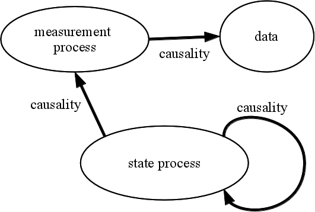

**Structure of a POMP.** Arrows show the direction of causality. The closed loop from the state process to itself indicates the dynamic nature of this Markovian process. Information flow runs in the opposite direction.

Mathematically, a POMP is characterized by two conditions.

1. The state process, $X_n$, is Markovian, i.e.,
   $$\mathrm{Prob}[X_n|X_0,\dots,X_{n-1},Y_1,\dots,Y_{n-1}]=\mathrm{Prob}[X_n|X_{n-1}].$$
2. The measurements, $Y_n$, depend only on the state at that time:
   $$\mathrm{Prob}[Y_n|X_0,\dots,X_{n},Y_1,\dots,Y_{n-1}]=\mathrm{Prob}[Y_n|X_{n}],$$
   for all $n=1,\dots,N$.

These conditions can be represented schematically by the following diagram, which indicates the direct dependencies among model variables.

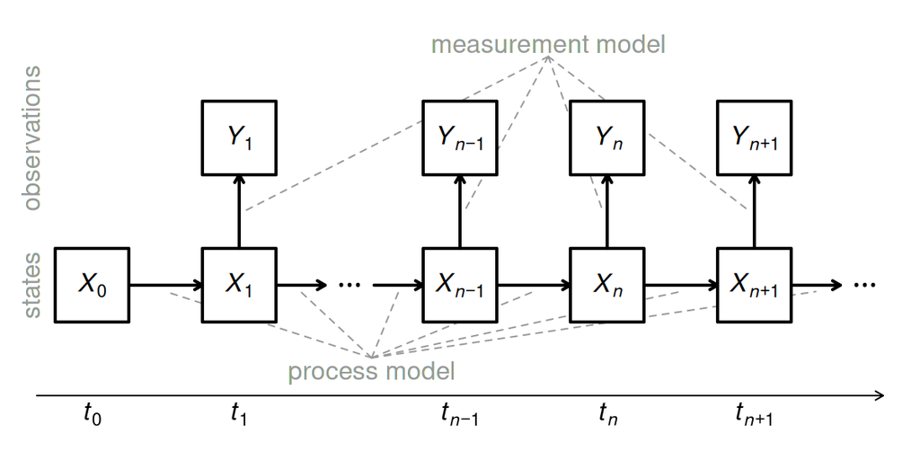

**Conditional independence graph of a POMP.** The latent state $X_n$ at time $t_n$ is conditionally independent of its history given $X_{n-1}$. The observation $Y_n$ is conditionally independent of all other variables given $X_n$. The underlying time scale can be taken to be either discrete or continuous and the observation times need not be equally spaced.

### Basic model components

To implement a POMP model in **pomp**, we have to specify the measurement and process distributions. Note however, that, for each of the process and the measurement models there are two distinct operations that we might desire to perform:

1. we might wish to *simulate*, i.e., to draw a random sample from the distribution, or
2. we might wish to *evaluate the density* itself at given values of $X_n$ and/or $Y_n$.

Following the **R** convention, we refer to the simulation of $f_{X_n|X_{n-1}}$ as the *rprocess* component of the POMP model and the evaluation of $f_{X_n|X_{n-1}}$ as the *dprocess* component. Similarly, the simulation of $f_{Y_n|X_n}$ is the *rmeasure* component while the evaluation of $f_{Y_n|X_n}$ is the *dmeasure* component. Finally, we’ll call a simulator of $f_{X_0}$ the *rinit* component. Collectively, we’ll refer to these, and other, similarly basic elements of the model, as the model’s *basic components*.

### The plug-and-play property

A method that makes no use of the *dprocess* component is said to be “plug-and-play” or to have the “plug-and-play property”. At present, **pomp** is focused on such methods, so there is no reason to discuss the dprocess component further in this document. In the following, we will illustrate and explain how one specifies the rprocess, rmeasure, and dmeasure components of a model in **pomp**. We will illustrate this using some simple examples.

## Preliminaries

### Installing the package

To get started, we must install **pomp**, if it is not already installed. See the [package website for installation instructions](https://kingaa.github.io/pomp/install.html).

### Important information for Windows and Mac users.

In this document, we will ultimately learn to implement POMP models using the package’s “C snippet” facility. This allows the user to write model components using snippets of C code, which is then compiled and linked into a running **R** session. This typically affords a manyfold increase in computation time. It is possible to avoid C snippets entirely by writing model components as **R** functions, and we will begin by doing so, but the speed-ups afforded by C snippets are typically too good to pass up. To use C snippets, you must be able to compile C codes. Compilers are not by default installed on Windows or Mac systems, so users of such systems must do a bit more work to make use of **pomp**’s facilities. The [installation instructions on the package website](https://kingaa.github.io/pomp/install.html) give details.

## Simulation of a POMP

Having dispensed with the preliminaries, we now explore some of the functionality provided by **pomp**. To assist the reader in following this exploration, the **R** codes for this document are available.

### The latent state process

Let us see how to implement a very simple POMP model. In particular, let’s begin by focusing on the famous Ricker model (Ricker 1954), which posits a nonlinear relationship between the size, $N(t)$, of a population in year $t$ and its size, $N(t+1)$, one year later:
$$N(t+1)=r\,N(t)\,\exp\left(1-\frac{N(t)}{K}\right).\tag{1}$$
Here, $r$ and $K$ are constant parameters, usually termed the *intrinsic growth rate* and the *carrying capacity*, respectively. As written, this is a deterministic model: it does not allow for any variability in the population dynamics. Let’s modify the Ricker equation by assuming that $r$ is not constant, but instead has random variation from year to year. If we assume that the intrinsic growth rate varies from year to year as a lognormal random variable, we obtain
$$N(t+1)=r\,N(t)\,\exp\left(1-\frac{N(t)}{K}+\varepsilon(t)\right),\tag{2}$$
where $\varepsilon(t)\sim\mathrm{Normal}(0,\sigma)$. Note that we’ve introduced a new parameter, $\sigma$, which quantifies the intensity of the noise in the population dynamics. Ecologically speaking, Eq. 2 is a model with *environmental stochasticity*.

Typically, it is relatively straightforward to simulate a POMP model. To accomplish this in **pomp**, as we’ve already discussed, we specify the rprocess component of the model. We’ll also need to choose values for the model parameters, $r$, $K$, and $\sigma$. We’ll also need to make a choice regarding the initial condition, $N(0)$. The simplest choice is to treat $N(0)=N_0$ as a parameter.

```r
library(pomp)
```

```r
simulate(t0=0, times=1:20,
  params=c(r=1.2,K=200,sigma=0.1,N_0=50),
  rinit=function (N_0, ...) {
    c(N=N_0)
  },
  rprocess=discrete_time(
    function (N, r, K, sigma, ...) {
      eps <- rnorm(n=1,mean=0,sd=sigma)
      c(N=r*N*exp(1-N/K+eps))
    },
    delta.t=1
  )
) -> sim1
```

```
## Warning: 'rmeasure' unspecified: NAs generated.
```

Notice that we’ve specified the rinit and rprocess components of the model as functions. These functions take as arguments the relevant variables (whether these are state variables or parameters). Importantly, they return *named numeric vectors*. Names of variables and parameters are very important in **pomp**. Notice too that we’ve used the `discrete_time` function, which encodes the fact that our Ricker model is a discrete-time stochastic process (a Markov chain). The first argument of `discrete_time` is an **R** function encoding Eq. 2; the second argument specifies the discrete time-step.

Note also that the parameters are furnished in the form of a named vector, and that we’ve specified both `t0` and `times`. The former is the *initial time*, $t_0$, i.e., the time at which the initial conditions apply. Since our initial condition is that $N(0)=N_0$, our initial time is $t_0=0$. The `times` argument specifies the observation times $t_1,\dots,t_N$.

Finally, note that we received a warning about `NA` values being generated. We will soon see what this is about.

What sort of an object is `sim1`? If we print it, we see

```r
sim1
```

```
## <object of class 'pomp'>
```

`sim1` is evidently an object of class ‘pomp’. We refer to these as ‘pomp’ objects.

To get more insight into the structure of `sim1`, we can use `spy`:

```r
spy(sim1)
```

**pomp** provides methods for plotting ‘pomp’ objects. For example,

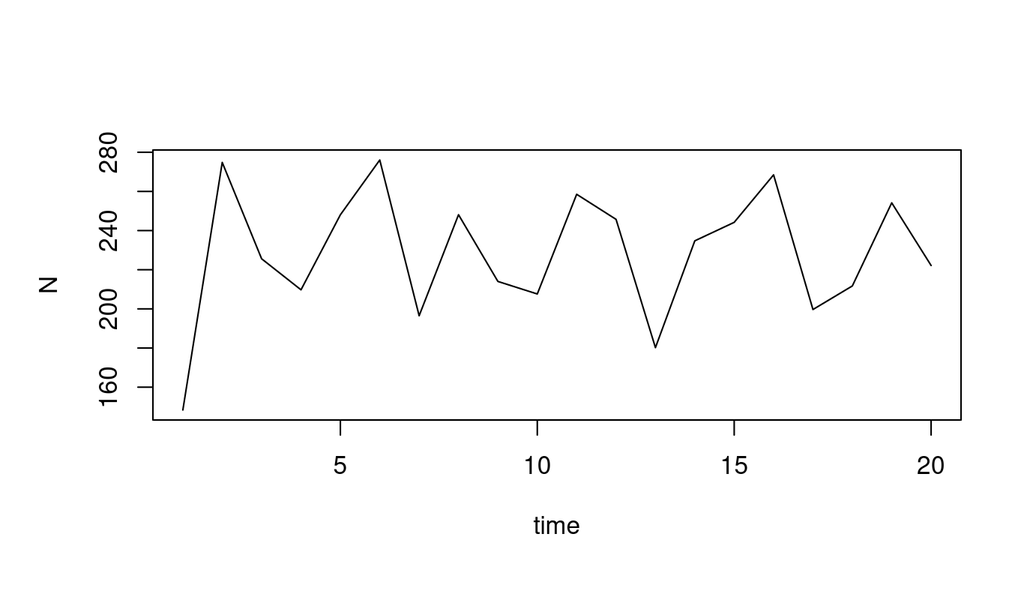

```r
plot(sim1)
```

We can also recast a ‘pomp’ object as a data frame:

```r
as(sim1,"data.frame")
```

| time | N |
| --- | --- |
| 1 | 148.3456 |
| 2 | 274.8027 |
| 3 | 225.5831 |
| 4 | 209.7361 |
| 5 | 248.0677 |
| 6 | 276.0464 |
| 7 | 196.4977 |
| 8 | 248.0970 |
| 9 | 214.0114 |
| 10 | 207.6063 |
| 11 | 258.5272 |
| 12 | 245.7282 |
| 13 | 180.2086 |
| 14 | 234.7697 |
| 15 | 244.2032 |
| 16 | 268.4648 |
| 17 | 199.6789 |
| 18 | 211.7116 |
| 19 | 254.1603 |
| 20 | 222.1691 |

Casting the ‘pomp’ object as a data frame allows us to use **ggplot2** graphics:

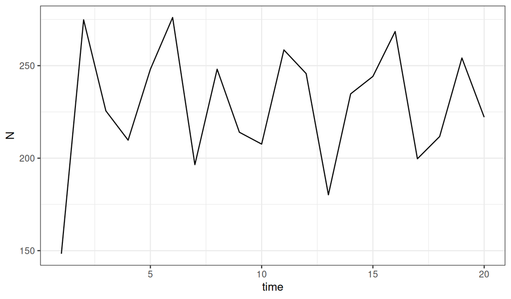

```r
ggplot(data=as.data.frame(sim1),aes(x=time,y=N))+
  geom_line()
```

Tp return to the warning we got when we ran `simulate`: it was telling us that `simulate` could not make a random draw from the measurement process because we had not supplied it with any information about this process. In particular, we had not supplied a measurement-model simulator. Let’s now see how to specify the measurement-model simulator, or rmeasure.

### The measurement model

Let’s suppose that non-lethal traps are used to sample the population to determine its size. Each year, some number of traps are set out and $Y_t$ is the number of animals captured. We might posit
$$Y_t\;\sim\;\mathrm{Poisson}(b\,N(t)),$$
where the parameter $b$ is proportional to sampling effort, e.g., the number of traps. This is a measurement model, and we can implement a simulator for it by specifying another function:

```r
simulate(t0=0, times=1:20,
  params=c(r=1.2,K=200,sigma=0.1,N_0=50,b=0.05),
  rinit=function (N_0, ...) {
    c(N=N_0)
  },
  rprocess=discrete_time(
    function (N, r, K, sigma, ...) {
      eps <- rnorm(n=1,mean=0,sd=sigma)
      c(N=r*N*exp(1-N/K+eps))
    },
    delta.t=1
  ),
  rmeasure=function (N, b, ...) {
    c(Y=rpois(n=1,lambda=b*N))
  }
) -> sim2
```

Note that, again, the rmeasure function need take only the necessary arguments (and `...`) and must return a named numeric vector.

Now, in the preceding chunk of code where we construct `sim2`, there was some redundancy with our earlier construction of `sim1`. In particular, we specified the same values of `t0`, `times`, `rinit`, and `rprocess` as before. Since these specifications were stored in `sim1`, however, we could have simply *added* in just the new pieces. For example,

```r
simulate(
  sim1,
  params=c(r=1.2,K=200,sigma=0.1,N_0=50,b=0.05),
  rmeasure=function (N, b, ...) {
    c(Y=rpois(n=1,lambda=b*N))
  }
) -> sim2
```

As before, we can examine our handiwork:

```r
spy(sim2)
```

```r
as(sim2,"data.frame")
```

| time | Y | N |
| --- | --- | --- |
| 1 | 11 | 124.0831 |
| 2 | 13 | 200.2960 |
| 3 | 7 | 267.4025 |
| 4 | 8 | 190.2190 |
| 5 | 12 | 195.8285 |
| 6 | 15 | 293.0790 |
| 7 | 14 | 216.3693 |
| 8 | 10 | 217.2981 |
| 9 | 12 | 269.7404 |
| 10 | 16 | 223.0512 |
| 11 | 11 | 200.4050 |
| 12 | 18 | 255.2297 |
| 13 | 12 | 231.3550 |
| 14 | 12 | 197.5631 |
| 15 | 14 | 263.8953 |
| 16 | 14 | 277.9194 |
| 17 | 15 | 197.6269 |
| 18 | 14 | 292.5811 |
| 19 | 13 | 250.8353 |
| 20 | 12 | 206.4404 |

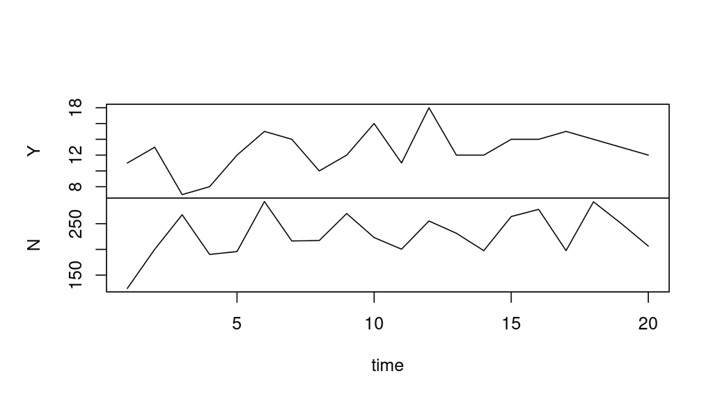

```r
plot(sim2)
```

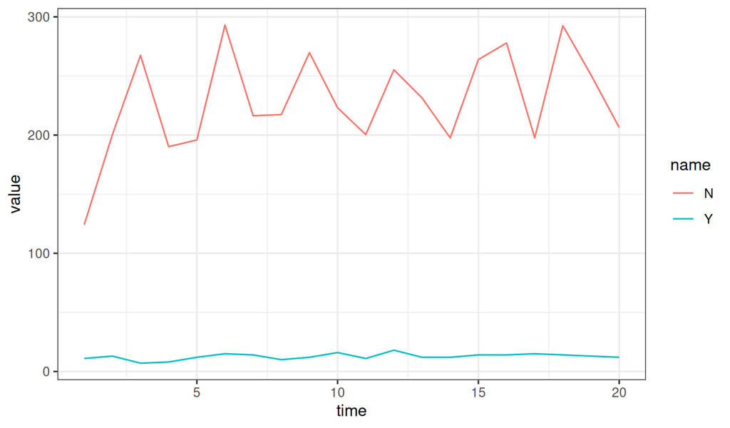

```r
ggplot(data=pivot_longer(as(sim2,"data.frame"),-time),
  aes(x=time,y=value,color=name))+
  geom_line()
```

Notice that now our `simulate` call produces samples from both the $N$ and the $Y$ distributions. `simulate` will try to sample from the joint distribution of latent states and observables, but will sample from just the latent state process if the rmeasure component is undefined.

### Multiple simulations

We can run multiple simulations using the same parameters:

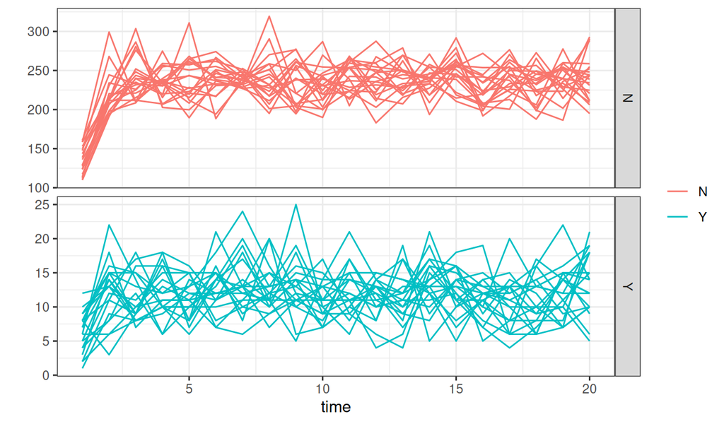

```r
simulate(sim2,nsim=20) -> sims

ggplot(data=pivot_longer(
         as.data.frame(sims),
         c(Y,N)
       ),
  aes(x=time,y=value,color=name,
    group=interaction(.L1,name)))+
  geom_line()+
  facet_grid(name~.,scales="free_y")+
  labs(y="",color="")
```

We can also run a single simulation from multiple parameters:

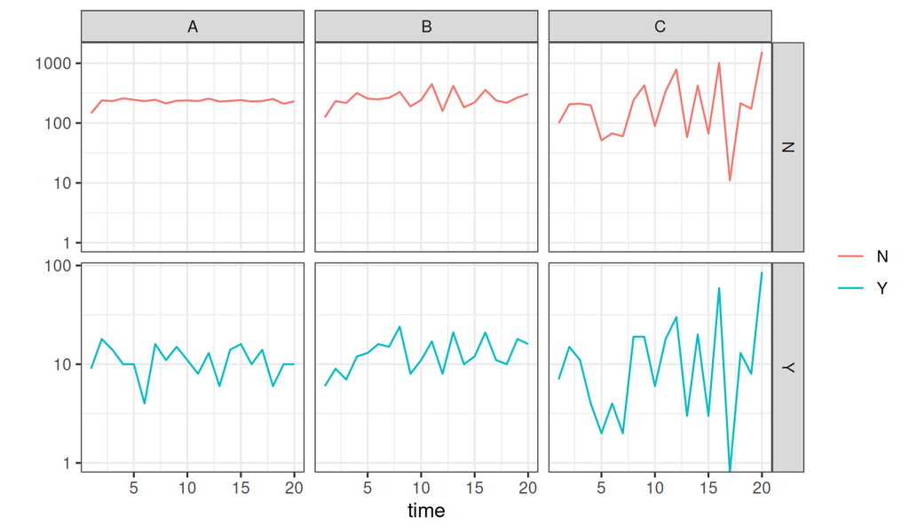

```r
p <- parmat(coef(sim2),3)
p["sigma",] <- c(0.05,0.25,1)
colnames(p) <- LETTERS[1:3]

simulate(sim2,params=p,format="data.frame") -> sims
sims <- pivot_longer(sims,c(Y,N))
ggplot(data=sims,aes(x=time,y=value,color=name,
  group=interaction(.id,name)))+
  geom_line()+
  scale_y_log10()+
  expand_limits(y=1)+
  facet_grid(name~.id,scales="free_y")+
  labs(y="",color="")
```

In the above, `coef` extracts the parameter vector stored in `sim2`. `parmat` makes a matrix with columns that are copies this vector. The second line modifies this matrix so that the columns are a set of points in parameter space that lie along a line with increasing values of the $\sigma$ parameter.

We can even run multiple simulations at each one of a set of parameters:

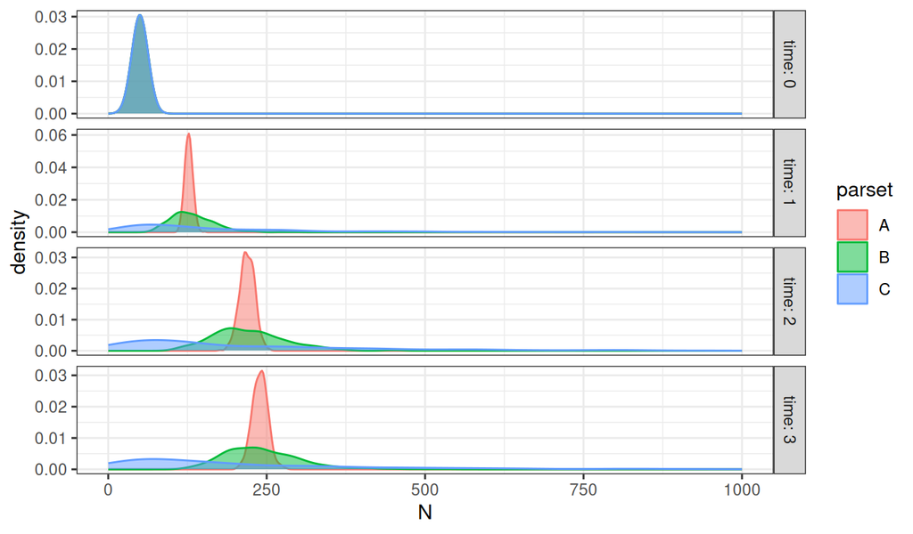

```r
simulate(sim2,params=p,
  times=seq(0,3),
  nsim=500,format="data.frame") -> sims
ggplot(data=separate(sims,.id,c("parset","rep")),
  aes(x=N,fill=parset,group=parset,color=parset))+
  geom_density(alpha=0.5)+
  # geom_histogram(aes(y=..density..),position="dodge")+
  facet_grid(time~.,labeller=label_both,scales="free_y")+
  lims(x=c(NA,1000))
```

## Note on **pomp** syntax

**pomp** uses certain syntactic conventions. For example, if `x` is an object and `f` is a **pomp** function, then typically `f(x,...) -> y` yields an object, `y`, that contains `x` plus the results of the `f` operation, together with additional information pertinent to what `f` did. Here, `...` stands for additional arguments to `f`. Then, if we call `f(y)`, this operation will perform some kind of repeat of the original operation: though the details will vary with `f` and `y`, choices made in the original computation (on `x`) will typically be respected. To change some of these choices, one can do `f(y,...)`, where the `...` stands for options of `f` that correspond to the new choices.

Morever, since `y` contains so much information, this information will typically be reused when we apply a different function, `g`, to `y`, when it makes sense to do so.

As of version 4.1 **R** provides a new pipe syntax that is especially convenient for us. It allows us to construct *pipelines* of **R** commands, which leads (once one is used to it) to code that is easier to read. In brief, a command in ordinary **R** style, such as

```
h(g(f(x,...),...),...)
```

where `f`, `g`, `h` are **R** functions, `x` is some **R** object, and `...` represents additional arguments to each of the functions, must be read from the inside out, which is at odds with the sequential nature of the `f` → `g` → `h` computation. An alternative, of course, is to write something like

```
y <- f(x,...)
z <- g(y,...)
w <- h(z,...)
```

which multiplies the entities (`y`, `z`, `w`) one must name and keep track of. In contrast, the new pipeline syntax of **R** allows us to write

```
x |> f(...) |> g(...) |> h(...)
```

The object-oriented structure of **pomp** makes this kind of programming quite natural.

Some experienced **R** programmers find the pipeline syntax uncomfortable or unnecessary at first, and debugging pipelined code requires a somewhat different approach. Of course, it is not necessary to adopt this style of programming to use **pomp**, but it is quite natural and, experience shows, quite addictive!

We will use pipelines freely for the remainder of the document.

*Important note:* If you opt to load the **tidyverse** (or individual packages therein), be sure to load **pomp** *after* loading these packages. There are some name conflicts between the packages that would otherwise cause **pomp** functions to be masked.

#### Exercise

Modify the `sim2` object constructed above to change the measurement model. In particular, assume that
$$Y_t\;\sim\;\mathrm{NegBin}(b\,N(t),\theta),$$
where $b$ and $\theta$ are parameters. (By this notation, we understand that $Y_t$ is negative binomially distributed with mean $b\,N(t)$ and variance $b\,N(t)+(b\,N(t))^2/\theta$.) Make and plot some simulations for $t=20,\dots,50$ with different values of the $\theta$ parameter. [Hint: use the `rnbinom` function with the `mu`, `size` parameterization.]

## *Parus major* population abundance data

We will illustrate some of the **pomp** data-analysis algorithms by performing a limited analysis on a set of bird abundance data. The data are from annual censuses of a population of *Parus major* (Great Tit) in Wytham Wood, Oxfordshire. They were retrieved as dataset #10163 from the Global Population Dynamics Database version 2 (NERC Centre for Population Biology, Imperial College, 2010). The original source is McCleery and Perrins (1991). They are provided as part of the package, in the data frame `parus`. Here we display the data graphically and in a table:

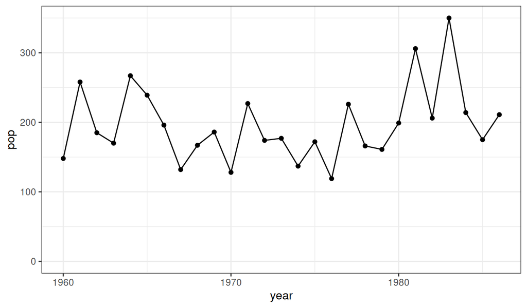

```r
parus |>
  ggplot(aes(x=year,y=pop))+
  geom_line()+geom_point()+
  expand_limits(y=0)
```

```r
parus
```

| year | pop |
| --- | --- |
| 1960 | 148 |
| 1961 | 258 |
| 1962 | 185 |
| 1963 | 170 |
| 1964 | 267 |
| 1965 | 239 |
| 1966 | 196 |
| 1967 | 132 |
| 1968 | 167 |
| 1969 | 186 |
| 1970 | 128 |
| 1971 | 227 |
| 1972 | 174 |
| 1973 | 177 |
| 1974 | 137 |
| 1975 | 172 |
| 1976 | 119 |
| 1977 | 226 |
| 1978 | 166 |
| 1979 | 161 |
| 1980 | 199 |
| 1981 | 306 |
| 1982 | 206 |
| 1983 | 350 |
| 1984 | 214 |
| 1985 | 175 |
| 1986 | 211 |

The basic data-type provided by **pomp**—the ‘pomp’ object—is designed as a container for a model and data. Let’s construct such an object with these data, together with the Ricker model we’ve already implemented. We do this with a call to the constructor function `pomp`:

```r
parus |>
  pomp(
    times="year", t0=1960,
    rinit=function (N_0, ...) {
      c(N=N_0)
    },
    rprocess=discrete_time(
      function (N, r, K, sigma, ...) {
        eps <- rnorm(n=1,mean=0,sd=sigma)
        c(N=r*N*exp(1-N/K+eps))
      },
      delta.t=1
    ),
    rmeasure=function (N, b, ...) {
      c(pop=rpois(n=1,lambda=b*N))
    }
  ) -> rick
```

Notice that the measurement model simulator (rmeasure) is not the same as before, reflecting the fact that the data are named `pop`, not `Y` as before. Also notice that we specify the time variable by name, thus allowing the data to dictate the observation times. The `t0` argument specifies that the stochastic latent state process is initialized in year 1960.

## Continuous-time process models

We’ve already shown how to implement a discrete-time model; let’s now see how to implement a continuous-time model. We’ll implement a very simple model of stable but stochastic population dynamics, the logistic, or Verhulst-Pearl, equation with environmental stochasticity. We’ll write this model as a stochastic differential equation (SDE), specifically an Itô diffusion:
$$dN =
r\,N\,\left(1-\frac{N}{K}\right)\,dt+\sigma\,N\,dW(t),\tag{3}$$
where $N$ is the population size, $r$ is a fixed rate, the so-called “Malthusian parameter”, $K$ is the population’s “carrying capacity”, $\sigma$ describes the intensity of extrinsic stochastic forcing on the system, and $dW$ is an increment of a standard Wiener process. [Those unfamiliar with Wiener processes and Itô diffusions will not go far wrong thinking of $dW(t)$, for each time $t$, as a normal random variable with mean zero and standard deviation $\sqrt{dt}$.] To implement this model in **pomp**, we must tell the package how to simulate this model. The easiest way to simulate such an SDE is via the *Euler-Maruyama* method. In this approximation, we take a large number of very small steps, each of duration $\Delta t$. At each step, we hold the right-hand side of the above equation constant, compute $\Delta N$ using that equation, and increment $N$ accordingly. **pomp** gives us the `euler` function to assist us in implementing the Euler-Maruyama method. To use it, we must encode the computations that take a single step. As before, we can do so by writing a function.

```r
vpstep <- function (N, r, K, sigma, delta.t, ...) {
  dW <- rnorm(n=1,mean=0,sd=sqrt(delta.t))
  c(N = N + r*N*(1-N/K)*delta.t + sigma*N*dW)
}
```

This function computes the value of $N(t+\Delta t)$ given the value of $N(t)$, $\Delta t$, and the parameters.

We fold this with the data into a ‘pomp’ object via a call to the ‘pomp’-object constructor function, `pomp`. We’ll also include the same measurement model we used before. Because everything but the ‘rprocess’ component is the same as with the Ricker model, to accomplish this, we can simply do

```r
rick |> pomp(rprocess=euler(vpstep,delta.t=1/365)) -> vp
```

Notice that we’ve specified an Euler-Maruyama step of about 1 day: it will take 365 of these steps to get us from one observation to the next.

As before, we can plot this ‘pomp’ object, recast it as a data frame, and simulate it for any given choice of the parameters.

#### Exercise

The following codes produce several simulations for parameters $r=0.5$, $K=2000$, $\sigma=0.1$ and $b=0.1$, and plot them on the same axes as the data. Notice that the `format="data.frame"` and `include.data=TRUE` options facilitate this. Vary the parameters to try to achieve a better fit to the data, as judged purely “by eye”.

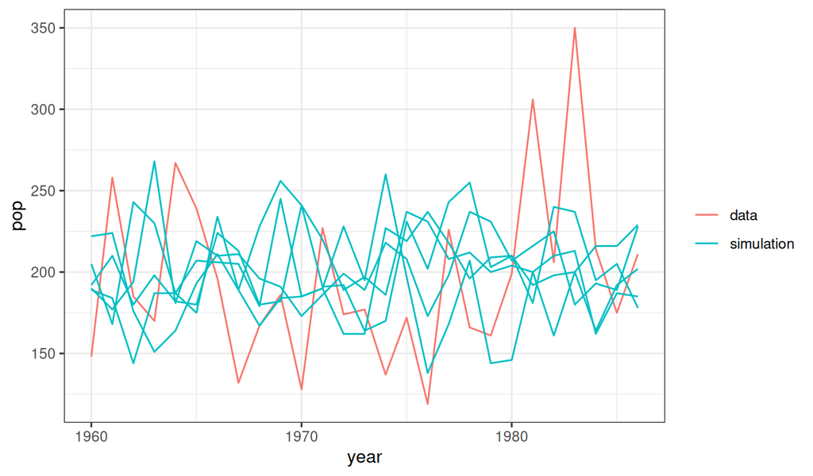

```r
vp |>
  simulate(
    params=c(r=0.5,K=2000,sigma=0.1,b=0.1,N_0=2000),
    format="data.frame", include.data=TRUE, nsim=5) |>
  mutate(ds=case_when(.id=="data"~"data",TRUE~"simulation")) |>
  ggplot(aes(x=year,y=pop,group=.id,color=ds))+
  geom_line()+
  labs(color="")
```

## C snippets

To this point, we’ve implemented two models by specifying their basic components as **R** functions. While this has the virtue of transparency, it puts severe constraints on computational performance due to intrinsic limits in the speed with which **R** codes can be interpreted. If all we want to do is run a few simulations, this is not a problem. As we’ll see, however, in attempting to perform parameter estimation and other inferences, we will need all the speed we can readily get. We achieve potentially massive speed-ups by implementing our basic model components in a language that can be compiled. **pomp** makes this easy. The key innovation is the C snippet. Let’s see how to code up the Ricker and Verhulst-Pearl models using C snippets. First, we’ll code up the rinit and rmeasure components, which the two models share.

```r
Csnippet("
  pop = rpois(b*N);
  ") -> rmeas

Csnippet("
  N = N_0;
  ") -> rinit
```

These are about as simple as one can get. As the name suggests, each is just a snippet of C code: not all variables are declared (in fact, in these examples, none are) and the context of the snippet is not specified. In particular, these snippets are not actually complete C functions, so by themselves, they cannot be compiled. They must not actually *violate* the rules of C syntax however. Among other things, lines must end with a semicolon (`;`), variable names must respect C restrictions, etc. Although one can enclose essentially arbitrarily complex C code in a C snippet, one can do quite a lot with very simple snippets. If you are new (even very new) to C, don’t worry: once you master a few simple rules, you’ll be able to code up C snippets just as easily, or even more easily, than you code up **R** functions and you will come to value the resulting speed-up extremely.

Now we’ll code the Ricker and Verhulst-Pearl simulation steps as C snippets.

```r
Csnippet("
  double eps = rnorm(0,sigma);
  N = r*N*exp(1-N/K+eps);
") -> rickstepC

Csnippet("
  double dW = rnorm(0,sqrt(dt));
  N += r*N*(1-N/K)*dt+sigma*N*dW;
") -> vpstepC
```

A few observations are in order. First, note that the local variables `eps` and `dW` are declared `double`, the standard C data-type for (double-precision) floating point numbers. Observe that `dt` is a variable that is defined in the context of the `vpstepC` snippet; when this snippet is executed, `dt` will be provided by `pomp` and will be equal to the size of the Euler step actually being taken. Note also that in each of these snippets, the value of `N` gets over-written by its new value at the next time-step. This is the goal of the C snippets we supply to specify the ‘rprocess’ component of a model. Finally, notice that neither the state variable `N` nor any of the parameters are declared. The declarations will be handled in a different way, as we’ll see in a moment.

When furnished with one or more C snippets, `pomp` will provide the necessary declarations and context, compile the resulting C code, dynamically link to it, and use it whenever the corresponding basic model component is needed. We cause all this to happen when we construct an object of class `pomp` via a call to the constructor function. Let’s do this for the two models now.

```r
parus |>
  pomp(
    times="year", t0=1960,
    rinit=rinit,
    rmeasure=rmeas,
    rprocess=discrete_time(rickstepC,delta.t=1),
    statenames="N",
    paramnames=c("r","K","sigma","b","N_0")
  ) -> rickC
```

```r
parus |>
  pomp(
    times="year", t0=1960,
    rinit=rinit,
    rmeasure=rmeas,
    rprocess=euler(vpstepC,delta.t=1/365),
    statenames="N",
    paramnames=c("r","K","sigma","b","N_0")
  ) -> vpC
```

In these calls, we use the `statenames` and `paramnames` arguments to indicate which of the undeclared variables in the C snippets `rickstepC` and `vpstepC` are state variables and which are fixed parameters. Since `dW` and `eps` are declared as local variables within the C snippets themselves, we don’t need to mention them here. The `rnorm` and `rpois` functions are part of the [**R** API](https://cran.r-project.org/doc/manuals/r-release/R-exts.html#The-R-API): see the [manual on “Writing R Extensions”](https://cran.r-project.org/doc/manuals/r-release/R-exts.html) for a description of these and the other [distribution functions provided as part of the **R** API](https://cran.r-project.org/doc/manuals/r-release/R-exts.html#Distribution-functions). A full set of rules for writing **pomp** C snippets is given in the package help (`?Csnippet`).

#### Exercise

Using the ‘pomp’ objects just constructed, explore model simulations at a variety of different parameters. As before, plot simulations and data on the same axes for comparison purposes.

#### Exercise

Write a C snippet implementing the negative binomial measurement model you explored previously. Fold it into the ‘pomp’ objects just constructed. Remember, there is no need to re-specify components you have already specified: by calling `pomp` on a ‘pomp’ object you can modify some or all of the basic model components. Plot simulations and data on the same axes, as in the immediately preceding exercise.

## The dmeasure component

As mentioned in the introduction, the dmeasure component is the other side of the rmeasure component. The latter simulates the measurement model whereas the former evaluates the measurement model’s probability density function. The following C snippet encodes the dmeasure component.

```r
Csnippet("
  lik = dpois(pop,b*N,give_log);
") -> dmeas
```

Here, `dpois` again comes from the [**R** API](https://cran.r-project.org/doc/manuals/r-release/R-exts.html#Distribution-functions). It takes three arguments, the datum (`pop`), the Poisson parameter (`b*N`), and `give_log`. When `give_log=0`, `dpois` returns the Poisson likelihood; when `give_log=1`, `dpois` returns the log of this likelihood. When this snippet is executed, `pomp` will provide the value of `give_log` according to its needs. It is the user’s responsibility to make sure that the correct value is returned for both possible values of `give_log`. **This is one of the most common places where newbies make mistakes!**

#### Exercise

Write the dmeasure component for your negative binomial model both as an **R** function and as a C snippet.

## The particle filter

We are now in a position to be able to compute the likelihood of the data given any set of parameters for either of our models. For this purpose, we use the *particle filter*. This powerful algorithm is at the heart of several of **pomp**’s inference methods. We won’t describe the theory of the particle filter here. The tutorial by Arulampalam, Maskell, Gordon, and Clapp (2002) explains the theory in an accessible way. The [**pomp** *Journal of Statistical Software*](https://kingaa.github.io/pomp/vignettes/pompjss.pdf) paper gives pseudocode and some examples. The [**pomp** documentation page](https://kingaa.github.io/pomp/docs.html) lists several other tutorial documents that go into more detail.

In **pomp**, the simplest version of the particle filter is implemented in the function `pfilter`. Its only required arguments are the ‘pomp’ object and the number of *particles*, i.e., the Monte Carlo sample size.

```r
rickC |>
  pfilter(Np=1000,
    params=c(r=1.2,K=2000,sigma=0.3,N_0=1600,b=0.1),
    dmeasure=dmeas,
    paramnames="b",statenames="N") -> pfrick
```

Notice that, in this call, we specified the dmeasure component using the C snippet we wrote above. What would have happened had we not specified this?

Notice that, because we here introduced a new C snippet, we again had to indicate which of the undeclared variables in `dmeas` are parameters and which are latent state variables.

What kind of object is `pfrick`?

```r
pfrick
```

```
## <object of class 'pfilterd_pomp'>
```

As a ‘pfilterd_pomp’ object, `pfrick` contains `rickC` plus a wealth of information regarding the particle filter operation that created it. For example, we can extract the estimated log likelihood at these (arbitrarily chosen) parameters:

```r
logLik(pfrick)
```

```
## [1] -148.5748
```

There is also a `plot` method for ‘pfilterd_pomp’ objects and one for coercing them to data frames.

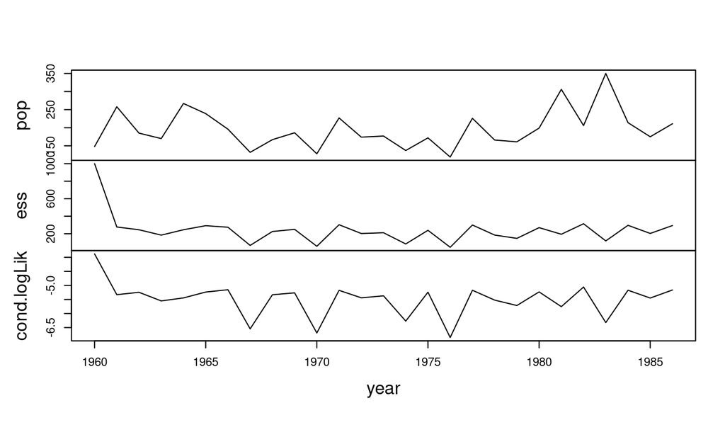

```r
plot(pfrick)
```

```r
as(pfrick,"data.frame")
```

| year | pop | ess | cond.logLik |
| --- | --- | --- | --- |
| 1960 | 148 | 1000.00000 | -3.879800 |
| 1961 | 258 | 276.91478 | -5.329129 |
| 1962 | 185 | 245.07346 | -5.244873 |
| 1963 | 170 | 183.89624 | -5.551510 |
| 1964 | 267 | 245.35009 | -5.443870 |
| 1965 | 239 | 291.78302 | -5.235775 |
| 1966 | 196 | 274.13378 | -5.152608 |
| 1967 | 132 | 66.23966 | -6.545454 |
| 1968 | 167 | 225.27473 | -5.331978 |
| 1969 | 186 | 249.96622 | -5.263931 |
| 1970 | 128 | 56.39030 | -6.692253 |
| 1971 | 227 | 302.62524 | -5.174603 |
| 1972 | 174 | 202.36717 | -5.441043 |
| 1973 | 177 | 211.26047 | -5.369764 |
| 1974 | 137 | 83.00157 | -6.269213 |
| 1975 | 172 | 238.82351 | -5.239950 |
| 1976 | 119 | 45.15378 | -6.853124 |
| 1977 | 226 | 299.48172 | -5.172145 |
| 1978 | 166 | 184.60553 | -5.521961 |
| 1979 | 161 | 146.71626 | -5.714835 |
| 1980 | 199 | 269.30266 | -5.230779 |
| 1981 | 306 | 193.94797 | -5.754881 |
| 1982 | 206 | 313.84250 | -5.057105 |
| 1983 | 350 | 117.75799 | -6.321934 |
| 1984 | 214 | 296.00247 | -5.170972 |
| 1985 | 175 | 203.08438 | -5.449372 |
| 1986 | 211 | 293.20228 | -5.161943 |

Both of these reveal that `pfrick` contains information about the *effective sample size* of the particle filter (`ess`) and the *conditional log likelihood*, `cond.logLik` which, in the notation introduced above, is
$$\log
f_{Y_n|Y_{1:n-1}}(y_n^*|y_{1:n-1}^*).$$

The particle filter is a Monte Carlo algorithm. Accordingly, it gives us only a noisy estimate of the likelihood. We can reduce this noise by increasing the number of particles, `Np`, and we can estimate the magnitude of the Monte Carlo error by running a few independent particle filters. For example:

```r
pfrick |> pfilter() |> logLik() |> replicate(n=10) -> lls
lls
```

```
##  [1] -148.4803 -148.5014 -148.8655 -148.6632 -149.2521 -148.1796 -148.0358
##  [8] -148.5363 -148.4578 -148.5291
```

```r
logmeanexp(lls,se=TRUE,ess=TRUE) -> ll_rick1
ll_rick1
```

```
##          est           se          ess
## -148.5019709    0.1004082    9.1782054
```

In the first line, notice that we did not need to specify `Np`, despite the fact that there is no default value of this parameter. Indeed, because `pfrick` is a ‘pfilterd_pomp’ object, it knows the value of `Np` that was used in its own creation. By default, this same value is used again when it is passed to `pfilter`. We could, of course, have used a different value simply by specifying `Np` in this call to `pfilter`.

The last line of the preceding code chunk computes the log of the mean of the estimated likelihoods and the standard error on this mean using a jack-knife method. Since the particle filter gives an unbiased estimate of the likelihood (not the log likelihood), this operation is sensible, provided the Monte Carlo error is not too large. It also estimates the “effective sample size”. The facts that this is close to the nominal sample size (10) and that the standard error is small relative to 1 log unit are both indications that the log likelihood is well estimated.

Let’s repeat the operation for the Verhulst-Pearl model, again at arbitrary parameters.

```r
vpC |>
  pfilter(Np=1000,dmeasure=dmeas,
    params=c(r=0.5,K=2000,sigma=0.1,b=0.1,N_0=2000),
    paramnames="b",statenames="N") |>
  logLik() |>
  replicate(n=10) |>
  logmeanexp(se=TRUE,ess=TRUE) -> ll_vp1
ll_vp1
```

[output not shown]

#### Exercise

Compute the likelihood for the parameters you found in your attempt to estimate parameters “by eye”.

## Trajectory matching

Trajectory matching is the method of estimating the parameters of a deterministic model by fitting the model to data assuming independent measurement errors. Although **pomp**’s main focus is on stochastic models, it does provide facilities for trajectory matching. **pomp** makes a conceptual distinction between the stochastic process and a *deterministic skeleton*, which we can view as a deterministic model related to the stochastic process’ central tendency. We’ll not go into mathematical details here: instead, we’ll illustrate with two examples.

### A discrete-time deterministic skeleton

A deterministic skeleton of the stochastic Ricker model is the Ricker map, Eq. 1. We implement this for **pomp**, again either as an **R** function or a C snippet and pass it to **pomp** functions via the `skeleton` argument. For example:

```r
rickC |>
  pomp(
    skeleton=map(
      Csnippet("DN = r*N*exp(1-N/K);"),
      delta.t=1
    ),
    paramnames=c("r","K"), statenames="N"
  ) -> rickC
```

Here, the left-hand side of Eq. 1 is indicated by the `D` prefix: in skeleton snippets, we don’t over-write the state variable `N`. We indicate that the skeleton is a discrete-time map using the `map` function.

### A continuous-time deterministic skeleton

A deterministic skeleton of the Verhulst-Pearl model is the vectorfield (or ordinary differential equation),
$$\frac{dN}{dt} =
r\,N\,\left(1-\frac{N}{K}\right).$$
We fold this into the `vpC` ‘pomp’ object so:

```r
vpC |>
  pomp(
    skeleton=vectorfield(Csnippet("DN = r*N*(1-N/K);")),
    paramnames=c("r","K"), statenames="N"
  ) -> vpC
```

Since the skeleton here is a vectorfield, in this C snippet, `DN` is filled with the value of the time-derivative of `N`. See the package help (`?Csnippet`) for a complete set of rules for writing C snippets.

### Trajectories of the deterministic skeleton

With the deterministic skeleton in place we can generate trajectories of the skeleton using `trajectory`. For example:

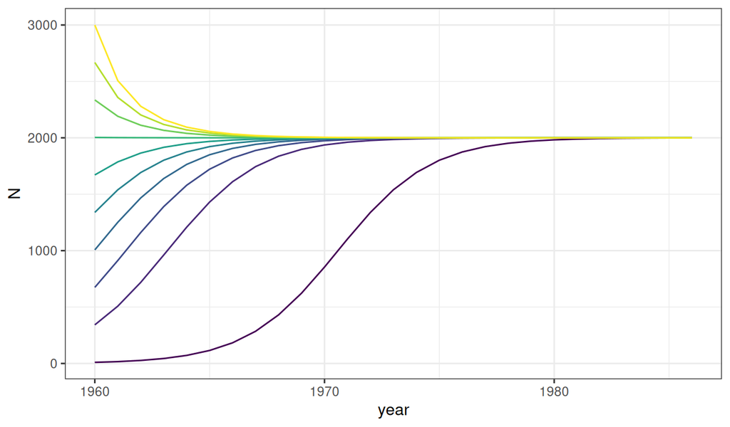

```r
p <- parmat(c(r=0.5,K=2000,sigma=0.1,b=0.1,N_0=2000),10)
p["N_0",] <- seq(10,3000,length=10)
vpC |>
  trajectory(params=p,format="data.frame") |>
  ggplot(mapping=aes(x=year,y=N,color=.id,group=.id))+
  guides(color="none")+
  geom_line()+
  theme_bw()
```

As with `simulate`, one can use `trajectory` to compute multiple trajectories at once, for varying values of the parameters.

### Parameter estimation using trajectory matching

In **pomp**, the function `traj_objfun` constructs an objective function quantifying the mismatch between model predictions and data. For this purpose, it uses the dmeasure component of the model. This function can be given to any of the large variety of numerical optimizers available in **R** and **R** packages. These optimizers search parameter space to find parameters under which the likelihood of the data, given a trajectory of the deterministic skeleton, is maximized.

We’ll demonstrate using the Verhulst-Pearl model.

```r
vpC |>
  traj_objfun(
    est=c("K","N_0"),
    params=c(r=0.5,K=2000,sigma=0.1,b=0.1,N_0=2000),
    dmeasure=dmeas, statenames="N", paramnames="b"
  ) -> ofun
```

Notice that, in this code chunk, we had to specify `dmeasure` once again. Why? What would have happened had we not done so?

What kind of object is `ofun`?

```r
ofun
```

```
## <object of class 'traj_match_objfun'>
```

‘traj_match_objfun’ objects, like the objective functions created by the **pomp** functions `spect_objfun`, `probe_objfun`, and `nlf_objfun`, is an **R** function, but it is also more than an **R** function. It contains not only the `vpC` ‘pomp’ object, but it additionally saves information each time it is evaluated. Let’s see how such *stateful* objective functions make it easy to use a wide range of numerical optimization routines.

We can evaluate `ofun` at any point in the 2-dimensional $K$-$N_0$ space. For example:

```r
ofun(c(1000,3000))
```

```
## [1] 1161.543
```

The value returned by `ofun` is the *negative* log likelihood, as returned by the model’s dmeasure component. We can estimate the parameters using, for example, the *subplex* algorithm implemented in the **subplex** package:

```r
library(subplex)

subplex(c(2000,1500),fn=ofun) -> fit
fit
```

```
## $par
## [1] 1968.474 1895.245
##
## $value
## [1] 276.2893
##
## $counts
## [1] 318
##
## $convergence
## [1] 0
##
## $message
## [1] "success! tolerance satisfied"
##
## $hessian
## NULL
```

Note that `fit` contains, among other things, the estimated parameters (element `par`) and the minimized value of the negative log likelihood (`value`).

To make absolutely certain that `ofun` remembers these estimates, we evaluate it once at `fit$par`:

```r
ofun(fit$par)
```

```
## [1] 276.2893
```

```r
coef(ofun)
```

```
##        r        K    sigma        b      N_0
##    0.500 1968.474    0.100    0.100 1895.245
```

```r
logLik(ofun)
```

```
## [1] -276.2893
```

Then we can, for example, extract the fitted trajectory thus:

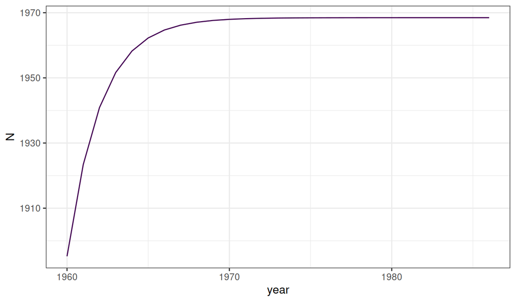

```r
ofun |>
  trajectory(format="data.frame") |>
  ggplot(mapping=aes(x=year,y=N,color=.id,group=.id))+
  guides(color="none")+
  geom_line()+
  theme_bw()
```

We can superimpose the model predictions on the data as follows.

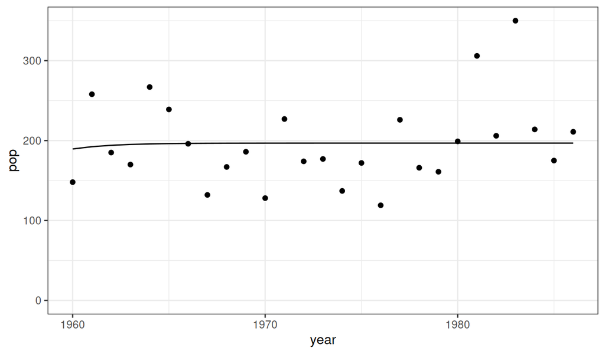

```r
ofun |>
  trajectory(format="data.frame") |>
  mutate(
    pop=coef(ofun,"b")*N,
    .id="prediction"
  ) |>
  select(-N) |>
  rbind(
    parus |>
      mutate(
        .id="data",
        pop=as.double(pop)
      )
  ) |>
  pivot_wider(names_from=.id,values_from=pop) |>
  ggplot(aes(x=year))+
  geom_line(aes(y=prediction))+
  geom_point(aes(y=data))+
  expand_limits(y=0)+
  labs(y="pop")
```

## Parameter transformations

Very commonly, model parameters must obey certain constraints. For example, the parameters in the two models we’ve looked at so far are all constrained to be positive. In estimating parameters, however, one frequently wants to employ a numerical optimization method that does not respect constraints. One way of accomodating such *unconstrained optimizers* is to transform the parameter space so that the constraints disappear. For example, by log-transforming the $r$ parameter in the Verhulst-Pearl model (Eq. 3), one obtains the superficially different equation
$$dN =
e^\rho\,N\,\left(1-\frac{N}{K}\right)\,dt+\sigma\,N\,dW(t),$$
where $\rho=\log{r}$. In this model, $\rho$ can take any (positive or negative) values while $r$ remains positive.

We incorporate parameter transformations using the `partrans` argument to many **pomp** functions, specifying them using the `parameter_trans` function. In general, the parameter transformations, like other basic model components, can be supplied using **R** functions or C snippets. If we are merely log-transforming, logit-transforming, or log-barycentric-transforming parameters, however, it is even easier. The following code chunk implements log transformation of all of the parameters of the Verhulst-Pearl and Ricker models.

```r
vpr_partrans <- parameter_trans(log=c("r","K","sigma","b","N_0"))
```

We could then provide `vpr_partrans` as needed to any of the various **pomp** inference methods, via the `partrans` argument. For example, to estimate parameters for the Verhulst-Pearl model on the transformed scale, we do

```r
vpC |>
  traj_objfun(
    est=c("b","K","N_0"),
    params=c(r=0.5,K=2000,sigma=0.1,b=0.1,N_0=2000),
    partrans=parameter_trans(log=c("K","N_0","b")),
    dmeasure=dmeas, statenames="N", paramnames=c("b","K","N_0")
  ) -> ofun2

subplex(log(c(0.1,2000,1500)),fn=ofun2) -> fit
ofun2(fit$par)
```

```
## [1] 276.2893
```

```r
coef(ofun2)
```

```
##             r             K         sigma             b           N_0
##    0.50000000 2506.85237865    0.10000000    0.07852373 2413.59563164
```

#### Exercise

Estimate the parameters for the Verhulst-Pearl model assuming negative binomial errors. Do not attempt, at first, to estimate all parameters simultaneously. Focus on estimating $K$, $N_0$ and the parameters of the measurement model. It will probably be helpful to make use of parameter transformations to enforce the model constraints.

#### Exercise

Estimate some or all of the parameters of the Ricker model using trajectory matching. It is probably a good idea to use parameter transformations.

## Maximizing the likelihood by iterated filtering

Let us now turn to the main focus of the **pomp** package: parameter estimation for fully stochastic models. Iterated filtering is a method for maximizing the likelihood. The method was introduced in its original form by E. L. Ionides, Bretó, and King (2006), and was subsequently much improved by Edward L. Ionides, Nguyen, Atchadé, Stoev, and King (2015). The latter paper rigorously expounds the theory. An [updated version of the **pomp** *Journal of Statistical Software* paper](https://kingaa.github.io/pomp/vignettes/pompjss.pdf) provides pseudocode and a simple example. Finally, a [tutorial on the theory and practice](https://kingaa.github.io/sbied/mif/) is linked from the [**pomp** documentation index](https://kingaa.github.io/pomp/docs.html). Here, we confine ourselves to demonstrating how the IF2 algorithm (Edward L. Ionides et al. 2015) is applied to the toy examples we have been discussing.

### Local vs global search

The search for the maximum likelihood parameter estimates (MLE) is inherently a global one: the likelihood surface can (and often enough does) possess multiple local maxima, any of which might represent a plausible explanation of the data in hand. IF2, however, is a local search algorithm: essentially, it starts at a user-provided “guess” and attempts to move “uphill” toward the nearest local maximum it can find. To solve the global problem, therefore, it is advisable to run IF2 multiple times, starting from different “guesses”. By studying the results of such a calculation, one hopes to obtain not only the global MLE but, more importantly, an understanding of the shape of the likelihood surface itself.

We begin by constructing a large number of “guesses”. Our design is to distribute these around some multidimensional “box” that, we hope, contains the MLE. Importantly, although our hope is that the box we construct here embraces the MLE, our eventual success does not necessarily depend on it doing so: the IF2 algorithm will be free to search parameter space outside the box. We use the `sobol_design` function to construct an overdispersed sequence of points within the selected box.

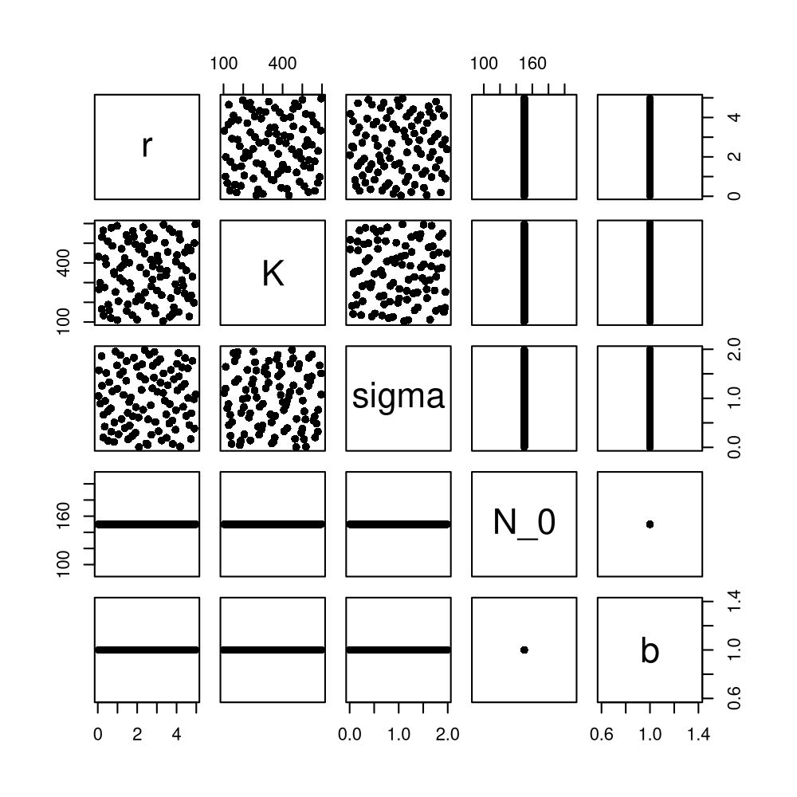

```r
sobol_design(
  lower=c(r=0,K=100,sigma=0,N_0=150,b=1),
  upper=c(r=5,K=600,sigma=2,N_0=150,b=1),
  nseq=100
) -> guesses

plot(guesses,pch=16)
```

In the above call, `lower` and `upper` give the bounds of the box and `nseq` specifies the number of guesses we desire. Now, from each of these starting guesses, we will run the IF2 algorithm (implemented as `mif2` in **pomp**). As its name suggests, this algorithm works by iteratively applying the particle filter: Crucially, IF2 adds an extra ingredient to the particle filter. As the filter is applied, IF2 adds random perturbations to the parameters. This serves several purposes, including smoothing the likelihood surface, combating particle depletion, and allowing IF2 to obtain information about the local structure of the surface. However, this augmented stochastic variability represents an alteration of the model. IF2 therefore gradually reduces the intensity of the random perturbations.

### Local search

Let us examine a single call to `mif2`.

```r
vpC |>
  mif2(
    params=guesses[1,],
    Np=1000,
    Nmif=20,
    dmeasure=dmeas,
    partrans=parameter_trans(log=c("r","K","sigma","N_0")),
    rw.sd=rw_sd(r=0.02,K=0.02,sigma=0.02,N_0=ivp(0.02)),
    cooling.fraction.50=0.5,
    paramnames=c("r","K","sigma","N_0","b"),
    statenames=c("N")
  ) -> vpM
```

In this call, we specify the starting point with `params`: here, we’ve just taken this to be the first of the `guesses`. As in `pfilter`, `Np` sets the number of particles to be used. `Nmif` fixes the number of IF2 iterations that will be performed. We furnish the necessary dmeasure component via the `dmeasure` argument, and provide parameter transformations via `partrans` to enforce positivity of the model parameters. The `rw.sd` argument specifies the intensity of the perturbations that will be applied at each observation time. The perturbations are normally distributed on the transformed (here, the log) scale, so these represent roughly 2% perturbations per observation. The `ivp` syntax indicates that `N_0` is an *initial value parameter* and accordingly should be treated slightly differently than the regular parameters. The `cooling.fraction.50` argument controls the speed at which the magnitude of the perturbations is drawn down. Finally, the `paramnames` and `statenames` arguments are needed since `dmeas` and the parameter transformations are built using C snippets.

What kind of object is `vpM`?

```r
vpM
```

```
## <object of class 'mif2d_pomp'>
```

**pomp** provides various methods for ‘mif2d_pomp’ objects. The `plot` method, for example, produces a diagnostic plot.

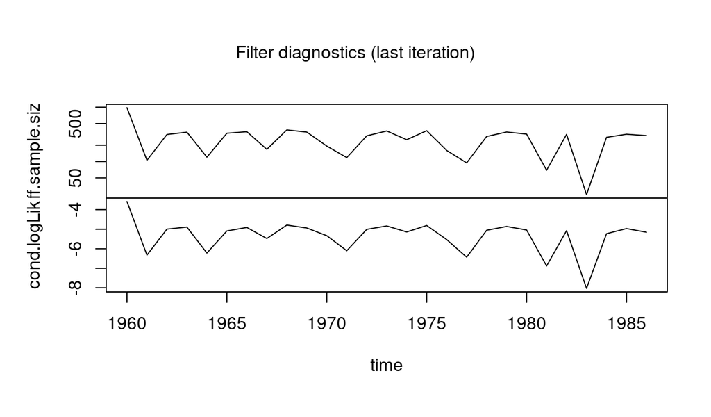

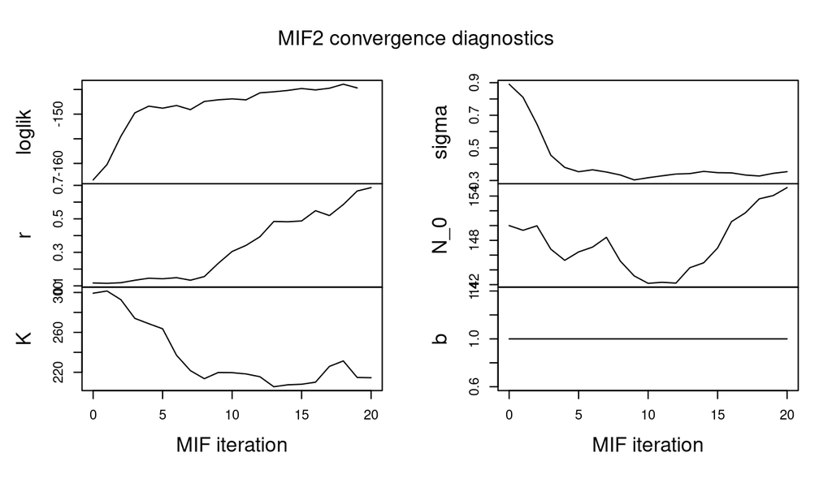

```r
plot(vpM)
```

The first plot (“filter diagnostics”) shows the results of the last iteration of the particle filter, comparable to the plot produced by calling `plot` on a ‘pfilterd_pomp’ object. The second plot (“convergence diagnostics”) summarizes the results of the sequence of IF2 iterations. We observe that the log likelihood has increased, concomitant with movement in the $r$, $K$, and $\sigma$ parameters and, to a lesser extent, the $N_0$ parameter. We observe that, as intended, the $b$ parameter has remained fixed.

### Estimating the log likelihood

Now, although we have observed the intended improvement in the log likelihood, we should be careful to note that the log likelihood displayed in this plot is the log likelihood of the *perturbed model*. This model differs from the one we are interested in. To compute the likelihood of our focal model at the parameter returned by `mif2`, we need to perform a few particle filter operations:

```r
vpM |> pfilter() |> logLik() |> replicate(n=5) |> logmeanexp(se=TRUE,ess=TRUE)
```

```
##          est           se          ess
## -143.9880041    0.1035849    4.7923226
```

Modern computers have multiple processors (cores). To take advantage of these, we can parallelize the above particle-filter computation using the **circumstance** and **doFuture** packages:

```r
library(circumstance)
library(doFuture)
plan(multicore)

vpM |> pfilter(Nrep=5) |> logLik() |> logmeanexp(se=TRUE,ess=TRUE)
```

```
##          est           se          ess
## -144.0370140    0.1467573    4.6030137
```

In the above, the `pfilter` function is provided by **circumstance**. It causes the particle filters to be run in parallel, each using a different core. Internally, **circumstance** uses the **doFuture** package to parallelize computations. **doFuture** provides a number of other ways of parallelizing computations, inclusing `multisession` (needed on Windows computers) and `cluster` (for parallelizing across multiple machines). These are set using the `plan()` function. **doFuture** also provides parallel random-number generators, so that we can consider each of the parallel computations to be independent.

#### Exercise

Use `circumstance::pfilter()` to parallelize the estimation of likelihood for your negative-binomial model.

### Global search

Now we repeat this calculation from each of our 100 guesses. Because these computations are each independent of the others, it is both easy and worthwhile to parallelize them. The **circumstance** package is also useful for this purpose. In particular, it defines a `mif2` method that takes a data frame of guesses of the kind we defined above. For each of these, it performs an iterated filtering computation.

```r
vpM |> mif2(starts=guesses) -> mifs
```

Notice that, in the above, the settings of `mif2` are not explicitly given here. They are inherited from `vpM`, which we computed previously. If we had wanted to modify any of them (e.g., `Nmif`, `Np`, `rw.sd`, etc.), we would have simply done so in the call to `mif2`. For example, to increase the number of particles and the number of iterations, we would do:

```r
vpM |>
  mif2(
    starts=guesses,
    Nmif=30,
    Np=2000
  ) -> mifs
```

Let us examine the results of our `mif2` computation. The following code chunk extracts the *traces* of the IF2 calculations. These are the movements of the parameters and the likelihood plotted against filter iteration.

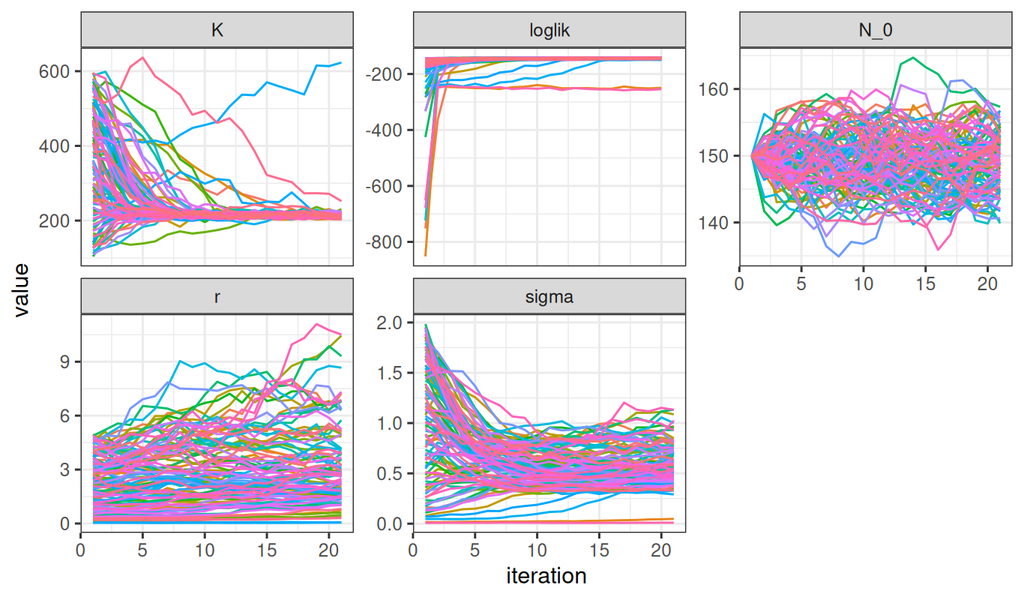

```r
mifs |>
  traces() |>
  melt() |>
  filter(name!="b") |>
  ggplot(aes(x=iteration,y=value,group=.L1,color=.L1))+
  geom_line()+
  facet_wrap(~name,scales="free_y")+
  guides(color="none")
```

More simply, executing `plot(mifs)`, would give us a less fancy plot.

Next, we examine the diagnostics produced in the last iteration of the filter.

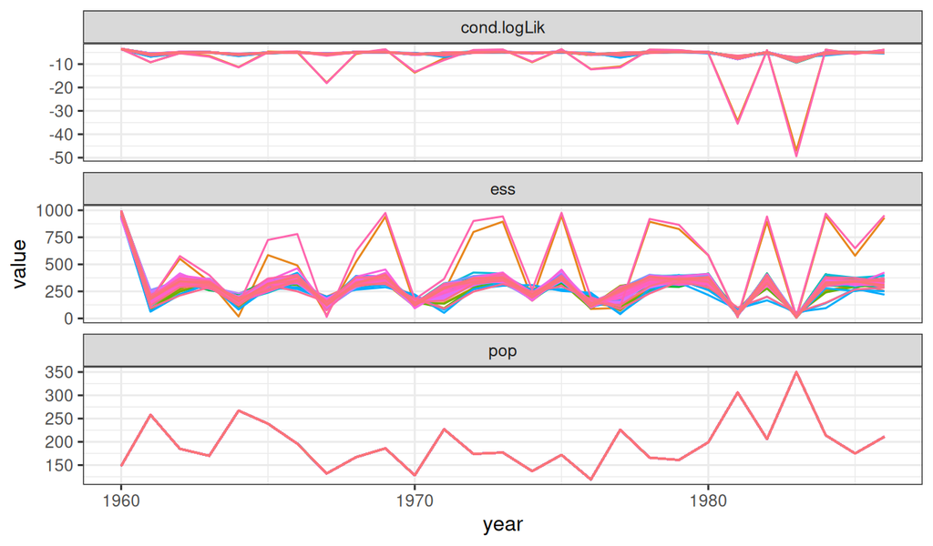

```r
mifs |>
  as("data.frame") |>
  pivot_longer(-c(.L1,year)) |>
  ggplot(aes(x=year,y=value,group=.L1,color=.L1))+
  geom_line()+
  facet_wrap(~name,scales="free_y",ncol=1)+
  guides(color="none")
```

Next, to estimate the log likelihoods, we run a few independent particle filters on the results of our `mif2` computations. We combine the resulting log likelihood estimates with the parameter estimates themselves (obtained using `coef()`).

```r
mifs |>
  pfilter(Nrep=5) |>
  logLik() |>
  melt() |>
  separate(name,into=c(".id","rep")) |>
  group_by(.id) |>
  reframe(melt(logmeanexp(value,se=TRUE))) |>
  ungroup() |>
  bind_rows(
    mifs |> coef() |> melt()
  ) |>
  pivot_wider() |>
  rename(
    loglik=est,
    loglik.se=se
  ) -> estimates
```

To display the results of such a multi-start search pairwise scatterplot matrices are useful:

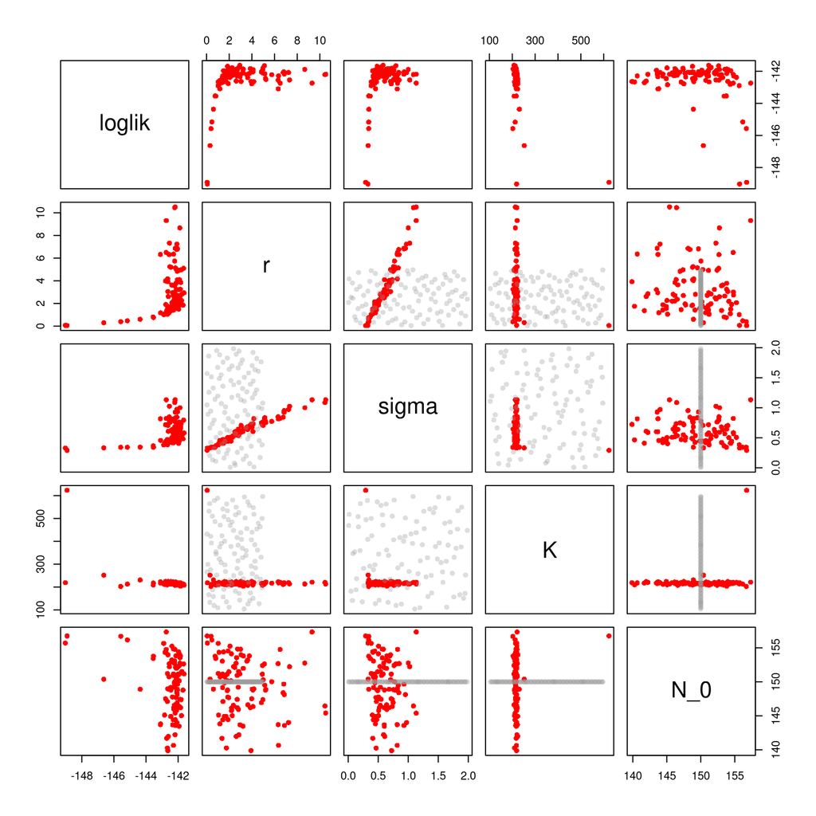

```r
estimates |>
  bind_rows(guesses) |>
  filter(is.na(loglik) | loglik>max(loglik,na.rm=TRUE)-30) |>
  mutate(col=if_else(is.na(loglik),"#99999955","#ff0000ff")) |>
  {
    \(dat) pairs(~loglik+r+sigma+K+N_0,data=dat,col=dat$col,pch=16)
  }()
```

### More search effort

At this point, there’s no particular reason to suspect that our IF2 searches have arrived at their destination. In general, it is hard to know *a priori* how much effort will be required to find the MLE. Let’s continue the search, starting with the best points we’ve uncovered so far.

```r
estimates |>
  filter(!is.na(loglik)) |>
  filter(loglik > max(loglik)-30) |>
  select(-.id,-loglik,-loglik.se) -> starts

vpM |>
  mif2(starts=starts) |>
  mif2() -> mf

mf |>
  pfilter(Nrep=5) |>
  logLik() |>
  melt() |>
  separate(name,into=c(".id","rep")) |>
  group_by(.id) |>
  reframe(melt(logmeanexp(value,se=TRUE))) |>
  ungroup() |>
  bind_rows(
    mf |> coef() |> melt()
  ) |>
  pivot_wider() |>
  rename(
    loglik=est,
    loglik.se=se
  ) -> ests1
```

We can combine the new estimates with the old ones into a general database:

```r
estimates |> bind_rows(ests1) |> select(-.id) -> estimates

estimates |> arrange(-loglik) |> head()
```

| loglik | loglik.se | r | K | sigma | N_0 | b |
| --- | --- | --- | --- | --- | --- | --- |
| -141.5075 | 0.1568272 | 2.750088 | 211.7153 | 0.5673722 | 150.4817 | 1 |
| -141.5692 | 0.0945215 | 7.293288 | 213.9672 | 0.8784366 | 149.6429 | 1 |
| -141.5906 | 0.1245422 | 5.800859 | 212.5148 | 0.8187268 | 145.5469 | 1 |
| -141.6074 | 0.1734127 | 2.463021 | 212.1082 | 0.5559576 | 142.4633 | 1 |
| -141.6324 | 0.0727712 | 2.935665 | 207.8947 | 0.5807423 | 151.1621 | 1 |
| -141.6597 | 0.3437959 | 5.101497 | 212.3675 | 0.7938931 | 152.6299 | 1 |

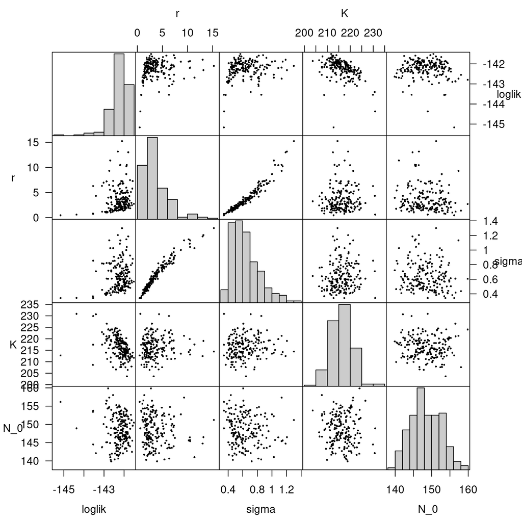

```r
estimates |>
  filter(loglik>max(loglik,na.rm=TRUE)-4) |>
  select(loglik,r,sigma,K,N_0) |>
  plot_matrix()
```

### Likelihood profile

We can improve the quality of our estimates and obtain likelihood-ratio-test-based confidence intervals by constructing *profile likelihoods*. In a likelihood profile, one varies the focal parameter (or parameters) across some range, maximizing the likelihood over the remaining parameters at each value of the focal parameter. The following codes construct a likelihood profile over $r$.

```r
estimates |>
  filter(loglik>max(loglik)-10) |>
  select(r,K,sigma,N_0,b) |>
  apply(2,range) -> ranges
ranges
```

```
##                r        K    sigma      N_0 b
## [1,]  0.05091814 202.5526 0.291154 139.8762 1
## [2,] 15.24609275 623.1927 1.300350 162.2693 1
```

```r
profile_design(
  r=10^seq(
    from=log10(ranges[1,1]),
    to=log10(ranges[2,1]),
    length=20
  ),
  lower=ranges[1,-1],
  upper=ranges[2,-1],
  nprof=50
) -> starts

dim(starts)
```

```
## [1] 1000    5
```

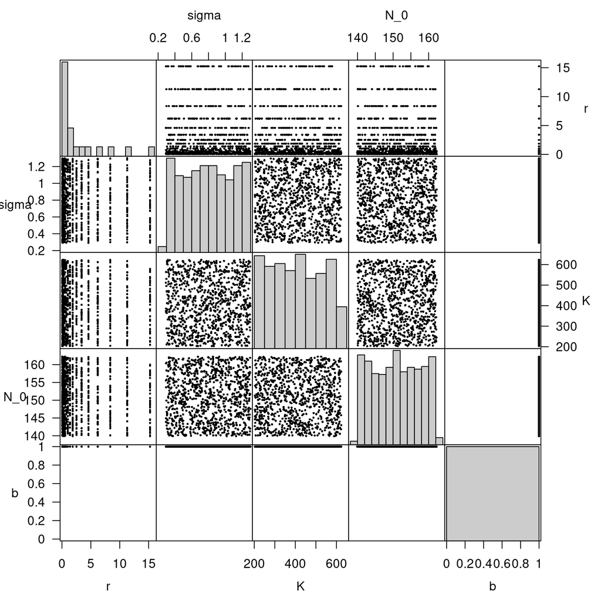

```r
starts |>
  select(r,sigma,K,N_0,b) |>
  plot_matrix()
```

```r
vpM |>
  mif2(
    starts=starts,
    partrans=parameter_trans(log=c("K","sigma","N_0")),
    rw.sd=rw_sd(K=0.02,sigma=0.02,N_0=ivp(0.02)),
    paramnames=c("K","sigma","N_0","b")
  ) |>
  mif2() -> mf

mf |>
  pfilter(Nrep=5) |>
  logLik() |>
  melt() |>
  separate(name,into=c(".id","rep")) |>
  group_by(.id) |>
  reframe(melt(logmeanexp(value,se=TRUE))) |>
  ungroup() |>
  bind_rows(
    mf |> coef() |> melt()
  ) |>
  pivot_wider() |>
  select(-.id) |>
  rename(
    loglik=est,
    loglik.se=se
  ) -> r_prof
```

Notice that we’ve changed the `mif2` perturbations (`rw.sd`): we’ve removed the perturbation on the $r$ parameter, since we want to hold this parameter fixed.

We add these points to our database:

```r
estimates |>
  bind_rows(r_prof) -> estimates
```

Next, we plot the likelihood profile. The following plot shows the top two estimates for each value of $r$ with error bars showing ±2 s.e. and a loess smooth.

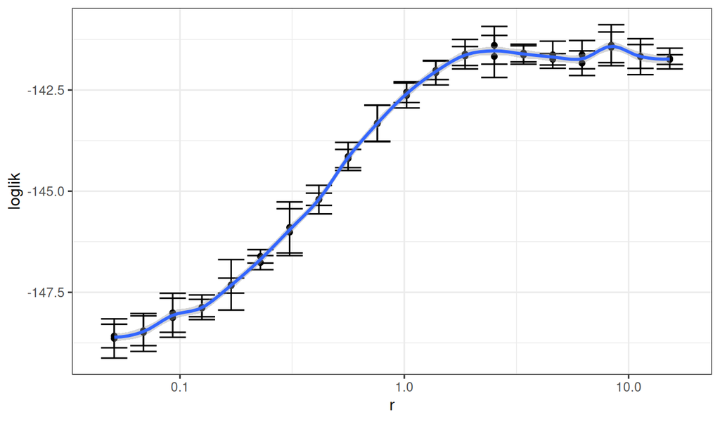

```r
r_prof |>
  group_by(r) |>
  filter(rank(-loglik)<=2) |>
  ungroup() |>
  ggplot(aes(x=r,y=loglik,
    ymin=loglik-2*loglik.se,ymax=loglik+2*loglik.se))+
  geom_point()+
  geom_errorbar()+
  geom_smooth(method="loess",span=0.2)+
  scale_x_log10()
```

We see that the 95% likelihood ratio test confidence interval (CI) appears to be one-sided: the CI is roughly $r>0.77$.

If we plot the *profile trace* of $\sigma$, we see that, as we increase $r$, we have to increase the intensity of the environmental stochasticity to maintain a good fit. Why is this?

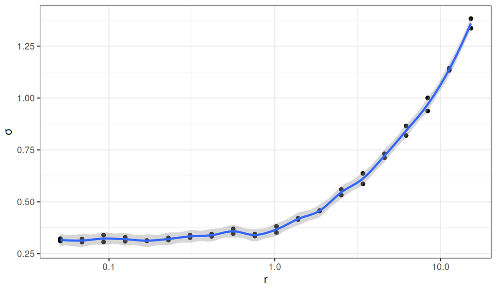

```r
r_prof |>
  group_by(r) |>
  filter(rank(-loglik)<=2) |>
  ungroup() |>
  ggplot(aes(x=r,y=sigma))+
  geom_point()+
  geom_smooth(method="loess",span=0.2)+
  scale_x_log10()+
  labs(y=expression(sigma))
```

#### Exercise

Construct a likelihood profile for the $K$ parameter. Plot the profile and profile traces. Comment on your findings.

## Hindcast and smoothing

To this point, we have focused on the particle filter as a means of computing the likelihood, for use in estimation of unknown parameters. It also gives us a way of estimating the likely trajectories of the latent state process. The `filter_mean`, `pred_mean`, and `pred_var` functions give access to the *filtering* and *prediction* distributions of the latent state at each observation time. The prediction distribution is that of $X_n\;\vert\;Y_1,\dots,Y_{n-1}$, i.e., the distribution of the latent state *conditional on* the observations at all times up to *but not including* $t_n$. The filter distribution, by contrast, incorporates the information of the $n$-th observation: it is the distribution of $X_n\;\vert\;Y_1,\dots,Y_n$.

One can think of the filtering distribution as a kind of *hindcast*, i.e., an estimate of the state of the latent process at earlier times. Although it is computed essentially at no additional cost, it is typically of limited value as a hindcast, since the amount of information used in the estimate decreases as one goes farther back into the past. A better hindcast is afforded by the *smoothing distribution*, which is the distribution of $X_n\;\vert\;Y_1,\dots,Y_N$, i.e., that of the latent state conditional on *all* the data.

Computation of the smoothing distribution requires more work. Specifically, a single particle chosen at random from a particle fitler, with its entire history, is a draw from the sampling distribution (Andrieu, Doucet, and Holenstein 2010). To build up a picture of the sampling distribution, therefore, one can run some number of independent particle filters, sampling a single particle’s trajectory from each. The following codes accomplish this. Note the use of the `filter_traj` function, which extracts the trajectory of a single, randomly chosen, particle.

```r
r_prof |>
  group_by(r) |>
  filter(rank(-loglik)<=2) |>
  ungroup() |>
  select(-loglik,-loglik.se) |>
  pivot_longer(-r) |>
  group_by(name) |>
  reframe(value=predict(loess(value~r),newdata=data.frame(r=2))) |>
  ungroup() |>
  pivot_wider() |>
  bind_cols(r=2) -> theta

bake(file="hindcast1.rds",seed=174423157,{
  vpM |>
    pfilter(params=theta,Np=500,Nrep=200,filter.traj=TRUE) -> pf
  list(
    loglik=logLik(pf),
    traj=filter_traj(pf)
  ) -> fts
}) -> fts

fts$loglik |> logmeanexp(se=TRUE,ess=TRUE)
```

```
##           est            se           ess
## -141.85949841    0.03826221  155.03489147
```

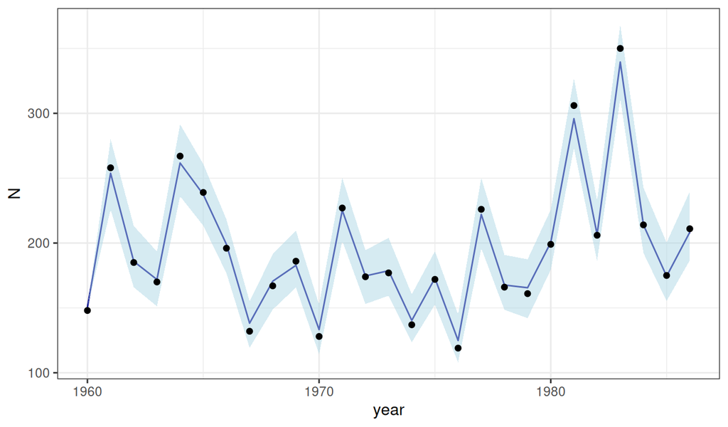

```r
fts$traj |>
  melt() |>
  select(-rep) |>
  left_join(
    tibble(
      chain=as.character(seq_along(fts$loglik)),
      loglik=fts$loglik
    ),
    by="chain"
  ) |>
  mutate(
    year=time(vpM)[time]
  ) |>
  group_by(name,year) |>
  reframe(
    label=c("lo","med","hi"),
    p=c(0.05,0.5,0.95),
    q=wquant(value,weights=exp(loglik-max(loglik)),probs=p)
  ) |>
  ungroup() |>
  select(-p) |>
  pivot_wider(names_from=label,values_from=q) -> quants1

quants1 |>
  ggplot()+
  geom_line(aes(x=year,y=med),color="darkblue")+
  geom_ribbon(aes(x=year,ymin=lo,ymax=hi),color=NA,fill="lightblue",alpha=0.5)+
  geom_point(data=parus,aes(x=year,y=pop))+
  labs(y="N")
```

Note also that the individual trajectories must we weighted by their Monte Carlo likelihoods (see the use of `wquant` in the above).

The plot above shows the uncertainty surrounding the hindcast. Importantly, this includes uncertainty due to both measurement error and process noise. It does not, however, incorporate parametric uncertainty. To fold this additional uncertainty into the estimates requires further work. We discuss this in a later section.

## Sampling the posterior using particle Markov chain Monte Carlo

### Running multiple `pmcmc` chains

If we seek to do full-information Bayesian inference, we can use particle Markov chain Monte Carlo, implemented in **pomp** in the `pmcmc` function. The following codes cause parallel pMCMC chains to be run, each beginning at one of the estimates obtained using `mif2`. Note that we add a prior by furnishing a prior probability density evaluation function (`dprior=...`). In this case, we assume a product prior: marginally uniform in each of the parameters $r$, $\sigma$, $K$, and $N_0$.

```r
r_prof |>
  group_by(r) |>
  filter(loglik==max(loglik)) |>
  ungroup() |>
  filter(
    r > 0.75,
    r < 6,
    sigma < 2,
    K > 100,
    K < 600,
    N_0 > 100,
    N_0 < 600
  ) |>
  select(-loglik,-loglik.se) -> starts
starts
```

| r | K | sigma | N_0 | b |
| --- | --- | --- | --- | --- |
| 0.7583159 | 212.4921 | 0.3449083 | 151.1379 | 1 |
| 1.0237195 | 206.1589 | 0.3819273 | 147.9725 | 1 |
| 1.3820120 | 214.8734 | 0.4208724 | 151.1844 | 1 |
| 1.8657037 | 208.9278 | 0.4556036 | 151.5757 | 1 |
| 2.5186830 | 208.5461 | 0.5325896 | 151.2567 | 1 |
| 3.4001991 | 210.7092 | 0.6369501 | 150.8489 | 1 |
| 4.5902378 | 209.2424 | 0.7314412 | 146.6463 | 1 |

```r
vpM |>
  pmcmc(
    starts=starts,
    Nmcmc=2000,Np=200,
    dprior=Csnippet(r"{
      lik = dunif(r,0,10,1)+dunif(sigma,0,2,1)+
            dunif(K,0,600,1)+dunif(N_0,0,600,1);
      lik = (give_log) ? lik : exp(lik);}"),
    paramnames=c("K","N_0","r","sigma"),
    proposal=mvn_rw_adaptive(
      rw.sd=c(r=0.02,sigma=0.02,K=50,N_0=50),
      scale.start=100,shape.start=100
    )
  ) -> chains

chains |>
  pmcmc(
    Nmcmc=20000,
    proposal=mvn_rw(covmat(chains))
  ) -> chains
```

In the above, we first subset out those `mif2` estimates that are consistent with our prior. At each of these, we then perform a number of MCMC moves, using an adaptive multivariate-normal random-walk proposal distribution `mvn.rw.adaptive`. To complete the inference, we do more MCMC iterations using a multivariate random-walk proposal (`mvn.rw`) with covariance matrix derived from the preceding computation (`covmat`).

### Convergence diagnostics

Now we investigate the chains, to try and determine whether they have converged.

```r
library(coda)
chains |> traces() -> traces
rejectionRate(traces[,c("r","sigma","K","N_0")])
```

```
##      r  sigma      K    N_0
## 0.8108 0.8108 0.8108 0.8108
```

```r
traces |> autocorr.diag(lags=c(1,5,10,50,100))
```

```
##             loglik log.prior           r           K       sigma         N_0
## Lag 1   0.92121471       NaN  0.92702720 0.893754641  0.92325877 0.916633944
## Lag 5   0.68580605       NaN  0.69890264 0.587984629  0.68036939 0.652331691
## Lag 10  0.49776447       NaN  0.50507504 0.368681424  0.47474171 0.432251677
## Lag 50  0.05911692       NaN  0.06229527 0.017739540  0.02615446 0.008046235
## Lag 100 0.01174881       NaN -0.01066084 0.009328191 -0.01527965 0.007167599
##           b
## Lag 1   NaN
## Lag 5   NaN
## Lag 10  NaN
## Lag 50  NaN
## Lag 100 NaN
```

```r
traces |> effectiveSize()
```

```
##    loglik log.prior         r         K     sigma       N_0         b
##  4763.848     0.000  4764.724  6967.900  5229.793  5886.642     0.000
```

```r
traces <- window(traces,thin=100,start=2000)
traces |> effectiveSize()
```

```
##    loglik log.prior         r         K     sigma       N_0         b
##  1339.787     0.000  1324.469  1267.000  1518.038  1460.035     0.000
```

The autocorrelation is strong, but drops to small values by lag 100. Accordingly, we thin the chains by a factor of 100. We discard 2000 iterations as a burn-in.

Now let us examine the traces.

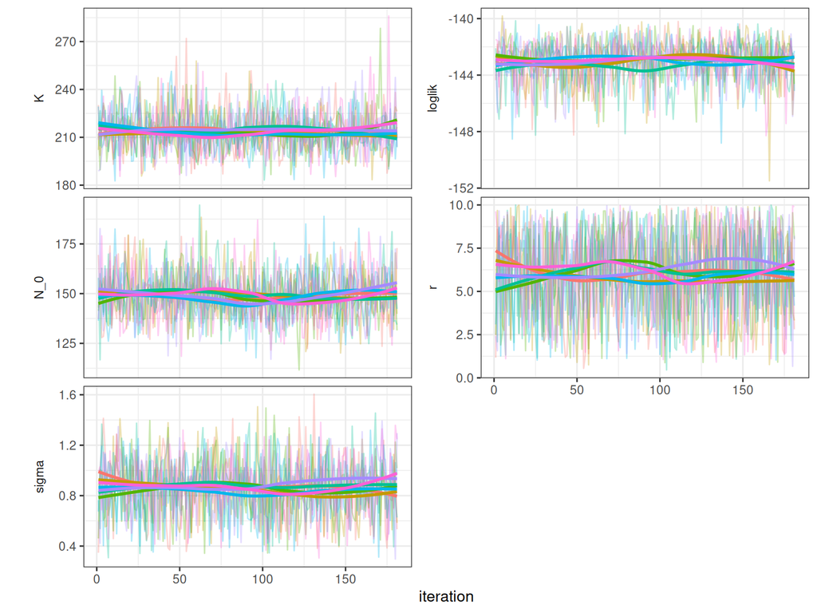

```r
traces |>
  lapply(as.data.frame) |>
  lapply(rowid_to_column,"iter") |>
  bind_rows(.id="chain") |>
  select(chain,iter,loglik,r,sigma,K,N_0) |>
  pivot_longer(c(-chain,-iter)) |>
  ggplot(aes(x=iter,group=chain,color=chain,y=value))+
  guides(color="none")+
  labs(x="iteration",y="")+
  geom_line(alpha=0.3)+geom_smooth(method="loess",se=FALSE)+
  facet_wrap(name~.,scales="free_y",strip.position="left",ncol=2)+
  theme(
    strip.placement="outside",
    strip.background=element_rect(fill=NA,color=NA)
  )
```

```r
gelman.diag(traces[,c("r","sigma","K","N_0")])
```

```
## Potential scale reduction factors:
##
##       Point est. Upper C.I.
## r          1.004       1.02
## sigma      1.007       1.02
## K          1.004       1.01
## N_0        0.998       1.00
##
## Multivariate psrf
##
## 1.01
```

The trace-plots show good mixing and the Gelman-Rubin statistic confirms that the chains are mixing among themselves: a good indicator of convergence. Thus, insofar as we can tell by these diagnostics, the MCMC iterations appear to have converged to their stationary distribution and we are sampling it well after thinning.

### Examining the posterior density

The plots of the marginal posterior densities are shown below.

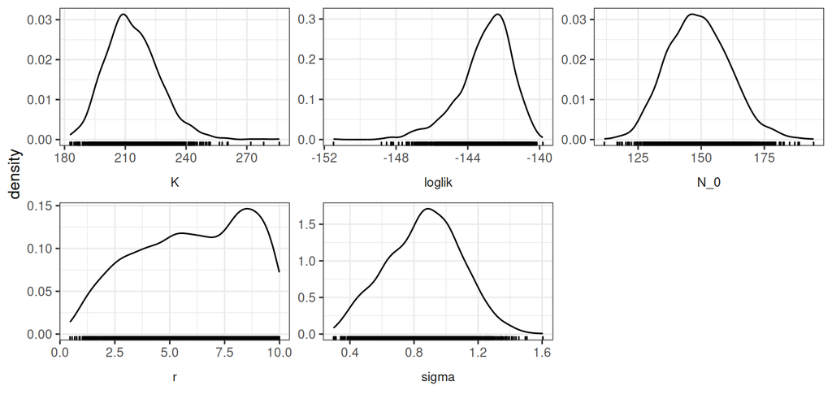

```r
traces |>
  lapply(as.data.frame) |>
  lapply(rowid_to_column,"iter") |>
  bind_rows(.id="chain") |>
  select(chain,iter,loglik,r,sigma,K,N_0) |>
  pivot_longer(c(-chain,-iter)) |>
  ggplot(aes(x=value))+
  geom_density()+
  geom_rug()+
  labs(x="")+
  facet_wrap(~name,scales="free",strip.position="bottom")+
  theme(
    strip.placement="outside",
    strip.background=element_rect(fill=NA,color=NA)
  )
```

```r
traces |> summary()
```

```
##
## Iterations = 2000:20000
## Thinning interval = 100
## Number of chains = 7
## Sample size per chain = 181
##
## 1. Empirical mean and standard deviation for each variable,
##    plus standard error of the mean:
##
##                Mean      SD Naive SE Time-series SE
## loglik    -143.0149  1.4770 0.041496        0.04140
## log.prior  -15.7896  0.0000 0.000000        0.00000
## r            6.0505  2.5254 0.070949        0.06972
## K          213.6117 13.2847 0.373219        0.37347
## sigma        0.8629  0.2308 0.006485        0.00610
## N_0        148.9236 12.2062 0.342919        0.32686
## b            1.0000  0.0000 0.000000        0.00000
##
## 2. Quantiles for each variable:
##
##                2.5%       25%       50%      75%    97.5%
## loglik    -146.6531 -143.7840 -142.7772 -141.984 -140.731
## log.prior  -15.7896  -15.7896  -15.7896  -15.790  -15.790
## r            1.3126    4.0112    6.2437    8.267    9.811
## K          191.5129  204.2935  212.2801  221.725  242.437
## sigma        0.4131    0.6959    0.8741    1.022    1.291
## N_0        127.0838  140.2798  148.5314  157.037  174.604
## b            1.0000    1.0000    1.0000    1.000    1.000
```

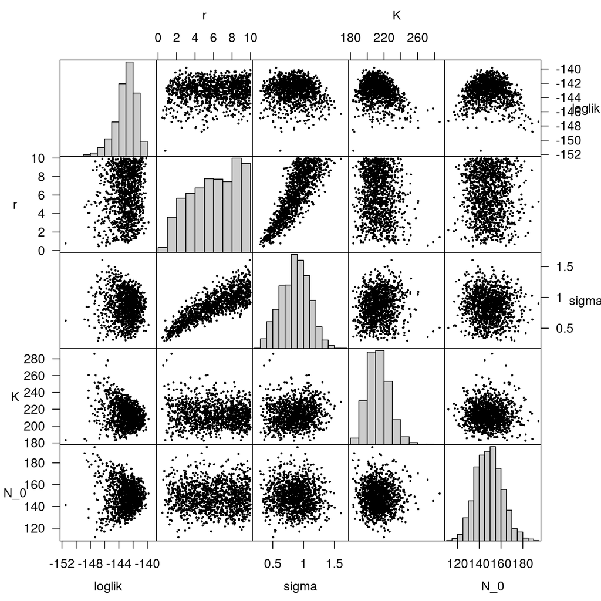

```r
traces |>
  lapply(as.data.frame) |>
  lapply(rowid_to_column,"iter") |>
  bind_rows(.id="chain") |>
  select(loglik,r,sigma,K,N_0) |>
  plot_matrix()
```

### Hindcast and smoothing with parametric uncertainty

Let us revisit the matter of hindcasting. In a preceding section, using an ensemble of particle filters, we were able to estimate the likely trajectory that the latent state process followed in generating the data we see, *conditional on a given parameter vector*. Naturally, since our estimate of the parameters is itself uncertain, our actual uncertainty regarding the hindcast is somewhat larger. We can use particle Markov chain Monte Carlo to fold in the parametric uncertainty. The following codes select one randomly-chosen particle trajectory from each iteration of our pMCMC chains. The chains are thinned and the burn-in period is discarded, of course. Note that it is not necessary to weight the samples by the likelihood: if the pMCMC chains have converged, the samples can be taken to be equally weighted samples from the smoothing distribution.

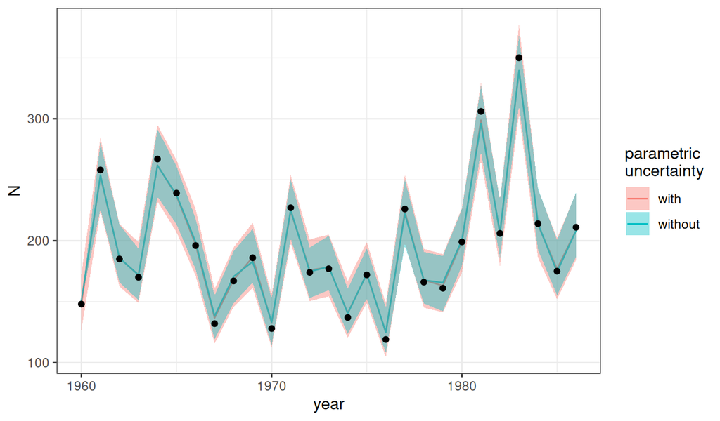

```r
chains |>
  filter_traj() |>
  melt() |>
  filter(rep > 1000, rep %% 100 == 0) |>
  mutate(year=time(vpM)[time]) |>
  pivot_wider(names_from=name) |>
  group_by(year) |>
  reframe(
    label=c("lo","med","hi"),
    p=c(0.025,0.5,0.975),
    q=wquant(N,probs=p)
  ) |>
  ungroup() |>
  select(-p) |>
  pivot_wider(names_from=label,values_from=q) -> quants2

bind_rows(
  with=quants2,
  without=quants1,
  .id="uncert"
) |>
  ggplot()+
  geom_line(aes(x=year,y=med,color=uncert))+
  geom_ribbon(aes(x=year,ymin=lo,ymax=hi,fill=uncert),color=NA,alpha=0.4)+
  geom_point(data=parus,aes(x=year,y=pop))+
  labs(y="N",fill="parametric\nuncertainty",color="parametric\nuncertainty")
```

## Model criticism

Estimating model parameters by fitting the model to data is typically only a step in the process of trying to understand the processes that generated the data. The next step involves trying to understand how and why the model fits the data the way it does, whether it fits it well, and what scope for improvement there might be. **pomp** provides a number of tools to facilitate answering these questions through interaction with a fitted model.

### Simulation of the fitted model

Ultimately, since the model is viewed, at least hypothetically, as the process that generated the data, simulation of the fitted model is a central tool we have for model criticism. Let’s plot the data and several simulated realizations of the model process on the same axes.

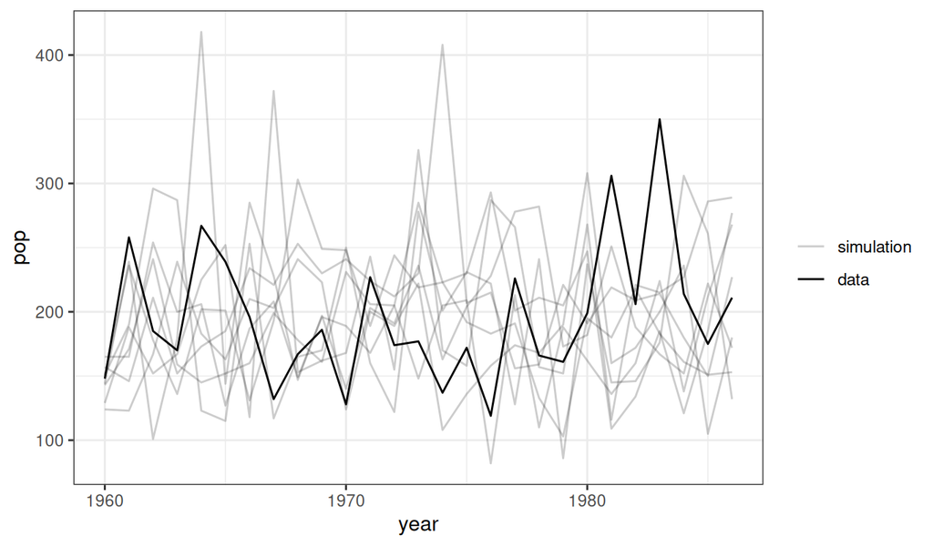

```r
r_prof |>
  filter(loglik==max(loglik)) -> mle

mlepomp <- as(mifs[[1]],"pomp")
coef(mlepomp) <- mle

mlepomp |>
  simulate(nsim=8,format="data.frame",include.data=TRUE) |>
  ggplot(mapping=aes(x=year,y=pop,group=.id,alpha=(.id=="data")))+
  scale_alpha_manual(values=c(`TRUE`=1,`FALSE`=0.2),
    labels=c(`FALSE`="simulation",`TRUE`="data"))+
  labs(alpha="")+
  geom_line()+
  theme_bw()
```

The first lines above simply extract the maximum likelihood estimates (`mle`) from our profle computation. The next pair of lines plug these MLE parameters into a ‘pomp’ object (`mlepomp`) containing the model and the data. The last set of lines do the simulation and the plotting.

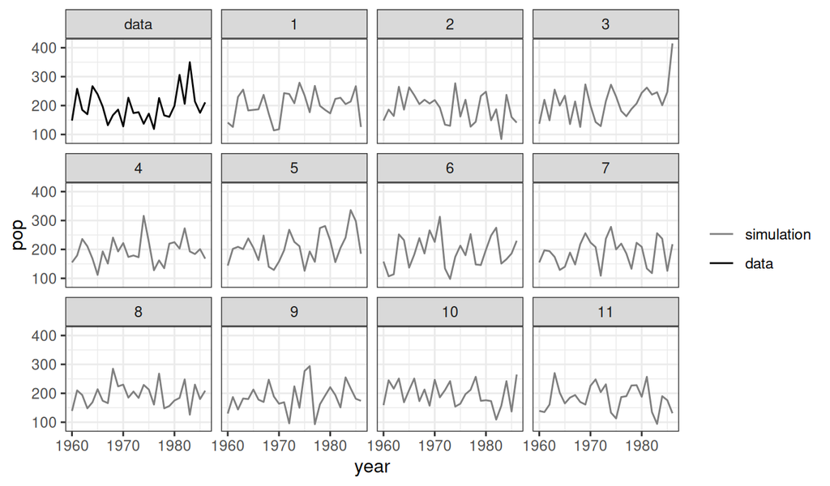

```r
mlepomp |>
  simulate(nsim=11,format="data.frame",include.data=TRUE) |>
  ggplot(mapping=aes(x=year,y=pop,group=.id,color=(.id=="data")))+
  scale_color_manual(values=c(`TRUE`="black",`FALSE`="grey50"),
    labels=c(`FALSE`="simulation",`TRUE`="data"))+
  labs(color="")+
  geom_line()+
  facet_wrap(~.id)+
  theme_bw()
```